# Resilience explore

Dan Killian

11/19/2021

# 1 Introduction

The South Sudan Monitoring and Evaluation Support Project (MESP) is conducting a household resilience survey in 13 counties. The purpose of this household survey is to obtain baseline data in the target areas for the indicators included in the Mission’s Performance Management Plan (PMP) and the Community Roadmap, in support of USAID/South Sudan’s Strategic Framework (2020-2024).

MESP has completed data collection in six counties, and as of October 2021 is carrying out data collection in the remaining seven counties. The study team is currently reviewing the data from six counties in advance of analysis of the full set of 13 counties. This document is one of a series of documents to review various measures and indices relating to resilience.

# 2 Resilience

## 2.1 Absorptive capacity

### 2.1.1 Community group participation

```r
grps <- dat %>%
  select(grp_water:grp_animalherding)

map(grps, frq)
```

```
## $grp_water
## x <numeric>
## # total N=7872 valid N=7811 mean=0.40 sd=0.49
##
## Value |    N | Raw % | Valid % | Cum. %
## ---------------------------------------
##     0 | 4662 | 59.22 |   59.69 |  59.69
##     1 | 3149 | 40.00 |   40.31 | 100.00
##  <NA> |   61 |  0.77 |    <NA> |   <NA>
##
## $grp_land
## x <numeric>
## # total N=7872 valid N=7810 mean=0.36 sd=0.48
##
## Value |    N | Raw % | Valid % | Cum. %
## ---------------------------------------
##     0 | 5003 | 63.55 |   64.06 |  64.06
##     1 | 2807 | 35.66 |   35.94 | 100.00
##  <NA> |   62 |  0.79 |    <NA> |   <NA>
##
## $grp_resource
## x <numeric>
## # total N=7872 valid N=7811 mean=0.20 sd=0.40
##
## Value |    N | Raw % | Valid % | Cum. %
## ---------------------------------------
##     0 | 6267 | 79.61 |   80.23 |  80.23
##     1 | 1544 | 19.61 |   19.77 | 100.00
##  <NA> |   61 |  0.77 |    <NA> |   <NA>
##
## $grp_credit
## x <numeric>
## # total N=7872 valid N=7811 mean=0.11 sd=0.31
##
## Value |    N | Raw % | Valid % | Cum. %
## ---------------------------------------
##     0 | 6986 | 88.74 |   89.44 |  89.44
##     1 |  825 | 10.48 |   10.56 | 100.00
##  <NA> |   61 |  0.77 |    <NA> |   <NA>
##
```

[output cut: 104 more lines]

```
## Value |    N | Raw % | Valid % | Cum. %
## ---------------------------------------
##     0 | 3914 | 49.72 |   50.15 |  50.15
##     1 | 3890 | 49.42 |   49.85 | 100.00
##  <NA> |   68 |  0.86 |    <NA> |   <NA>
##
## $grp_animalherding
## x <numeric>
## # total N=7872 valid N=7792 mean=0.44 sd=0.50
##
## Value |    N | Raw % | Valid % | Cum. %
## ---------------------------------------
##     0 | 4352 | 55.28 |   55.85 |  55.85
##     1 | 3440 | 43.70 |   44.15 | 100.00
##  <NA> |   80 |  1.02 |    <NA> |   <NA>
```

```r
frq(dat$grp_sum)
```

```
## x <numeric>
## # total N=7872 valid N=7656 mean=6.18 sd=4.16
##
## Value |   N | Raw % | Valid % | Cum. %
## --------------------------------------
##     0 | 641 |  8.14 |    8.37 |   8.37
##     1 | 467 |  5.93 |    6.10 |  14.47
##     2 | 632 |  8.03 |    8.25 |  22.73
##     3 | 654 |  8.31 |    8.54 |  31.27
##     4 | 659 |  8.37 |    8.61 |  39.88
##     5 | 656 |  8.33 |    8.57 |  48.45
##     6 | 565 |  7.18 |    7.38 |  55.83
##     7 | 500 |  6.35 |    6.53 |  62.36
##     8 | 554 |  7.04 |    7.24 |  69.59
##     9 | 542 |  6.89 |    7.08 |  76.67
##    10 | 452 |  5.74 |    5.90 |  82.58
##    11 | 380 |  4.83 |    4.96 |  87.54
##    12 | 347 |  4.41 |    4.53 |  92.07
##    13 | 239 |  3.04 |    3.12 |  95.19
##    14 | 144 |  1.83 |    1.88 |  97.07
##    15 |  92 |  1.17 |    1.20 |  98.28
##    16 | 132 |  1.68 |    1.72 | 100.00
##  <NA> | 216 |  2.74 |    <NA> |   <NA>
```

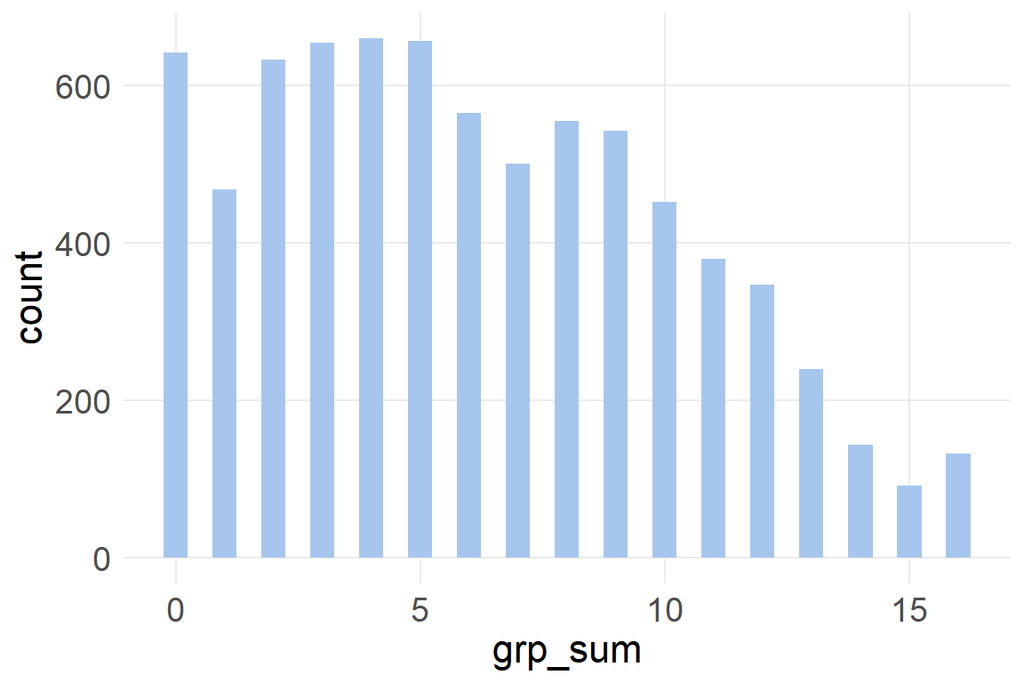

```r
ggplot(dat, aes(grp_sum)) +
  geom_bar(fill=light_blue,
           width=.5)
```

#### 2.1.1.1 rank frequencies

```r
names(grps)
```

```
##  [1] "grp_water"         "grp_land"          "grp_resource"
##  [4] "grp_credit"        "grp_savings"       "grp_help"
##  [7] "grp_relig"         "grp_mother"        "grp_women"
## [10] "grp_youth"         "grp_sports"        "grp_disaster"
## [13] "grp_raiding"       "grp_herding"       "grp_cattleprotect"
## [16] "grp_animalherding"
```

```r
grps_temp <- svyrdat %>%
  summarize(grp_water = survey_mean(grp_water, na.rm=T),
            grp_land  = survey_mean(grp_land, na.rm=T),
            grp_resource  = survey_mean(grp_resource, na.rm=T),
            grp_credit  = survey_mean(grp_credit, na.rm=T),
            grp_savings = survey_mean(grp_savings, na.rm=T),
            grp_help  = survey_mean(grp_help, na.rm=T),
            grp_relig  = survey_mean(grp_relig, na.rm=T),
            grp_mother  = survey_mean(grp_mother, na.rm=T),
            grp_women = survey_mean(grp_women, na.rm=T),
            grp_youth = survey_mean(grp_youth, na.rm=T),
            grp_sports  = survey_mean(grp_sports, na.rm=T),
            grp_disaster  = survey_mean(grp_disaster, na.rm=T),
            grp_raiding = survey_mean(grp_raiding, na.rm=T),
            grp_herding  = survey_mean(grp_herding, na.rm=T),
            grp_cattleprotect = survey_mean(grp_cattleprotect, na.rm=T),
            grp_animalherding  = survey_mean(grp_animalherding, na.rm=T))

grps_temp
```

Table 2.1:

| grp_water | grp_water_se | grp_land | grp_land_se | grp_resource | grp_resource_se | grp_credit | grp_credit_se | grp_savings | grp_savings_se | grp_help | grp_help_se | grp_relig | grp_relig_se | grp_mother | grp_mother_se | grp_women | grp_women_se | grp_youth | grp_youth_se | grp_sports | grp_sports_se | grp_disaster | grp_disaster_se | grp_raiding | grp_raiding_se | grp_herding | grp_herding_se | grp_cattleprotect | grp_cattleprotect_se | … |
| --- | --- | --- | --- | --- | --- | --- | --- | --- | --- | --- | --- | --- | --- | --- | --- | --- | --- | --- | --- | --- | --- | --- | --- | --- | --- | --- | --- | --- | --- | --- |
| 0.4 | 0.0194 | 0.402 | 0.0212 | 0.254 | 0.0192 | 0.094 | 0.00856 | 0.0813 | 0.00805 | 0.2 | 0.0146 | 0.674 | 0.0197 | 0.545 | 0.0209 | 0.62 | 0.0186 | 0.629 | 0.0171 | 0.367 | 0.0206 | 0.283 | 0.0161 | 0.358 | 0.0188 | 0.594 | 0.0184 | 0.579 | 0.0185 | … |

```r
grps_mn <- grps_temp %>%
  select(!contains("se")) %>%
  melt() %>%
  mutate(group = grp_labs) %>%
  select(1,3,2)


grps_se <- grps_temp %>%
  select(contains("se")) %>%
  melt() %>%
  rename(se=value)

grps_se
```

Table 2.2:

| variable | se |
| --- | --- |
| grp_water_se | 0.0194 |
| grp_land_se | 0.0212 |
| grp_resource_se | 0.0192 |
| grp_credit_se | 0.00856 |
| grp_savings_se | 0.00805 |
| grp_help_se | 0.0146 |
| grp_relig_se | 0.0197 |
| grp_mother_se | 0.0209 |
| grp_women_se | 0.0186 |
| grp_youth_se | 0.0171 |
| grp_sports_se | 0.0206 |
| grp_disaster_se | 0.0161 |
| grp_raiding_se | 0.0188 |
| grp_herding_se | 0.0184 |
| grp_cattleprotect_se | 0.0185 |
| grp_animalherding_se | 0.0181 |

```r
grps_sum <- grps_mn %>%
  cbind(grps_se[,2]) %>%
  rename(percent=value,
         se = 4) %>%
  mutate(lower=percent-1.96*se,
         upper=percent+1.96*se,
         item=grp_items) %>%
  arrange(desc(percent)) %>%
  relocate(item, .after=variable)

grps_sum <- read_csv(here("output/tables/resilience/groups weighted.csv"))

grps_sum_gt <- grps_sum %>%
  gt() %>%
  fmt_percent(4:7,
              decimals=1)



grps_sum_gt <- grps_sum %>%
  gt() %>%
  fmt_percent(4:7, decimals=1)

grps_sum_gt
```

| variable | item | group | percent | se | lower | upper |
| --- | --- | --- | --- | --- | --- | --- |
| grp_relig | q501g | Religious | 67.4% | 2.0% | 63.5% | 71.3% |
| grp_youth | q501j | Youth | 62.9% | 1.7% | 59.5% | 66.2% |
| grp_women | q501i | Women | 62.0% | 1.9% | 58.4% | 65.7% |
| grp_herding | q501n | Cattle herding | 59.4% | 1.8% | 55.8% | 63.0% |
| grp_cattleprotect | q501o | Cattle protection | 57.9% | 1.8% | 54.3% | 61.5% |
| grp_mother | q501h | Mothers | 54.5% | 2.1% | 50.4% | 58.5% |
| grp_animalherding | q501p | Small animal herding | 46.1% | 1.8% | 42.6% | 49.7% |
| grp_land | q501b | Grazing land users | 40.2% | 2.1% | 36.0% | 44.3% |
| grp_water | q501a | Water users | 40.0% | 1.9% | 36.2% | 43.8% |
| grp_sports | q501k | Sports | 36.7% | 2.1% | 32.7% | 40.8% |
| grp_raiding | q501m | Cattle raiding | 35.8% | 1.9% | 32.1% | 39.5% |
| grp_disaster | q501l | Disaster planning | 28.3% | 1.6% | 25.1% | 31.5% |
| grp_resource | q501c | Community natural resources | 25.4% | 1.9% | 21.7% | 29.2% |
| grp_help | q501f | Mutual help | 20.0% | 1.5% | 17.1% | 22.8% |
| grp_credit | q501d | Credit/microfinance | 9.4% | 0.9% | 7.7% | 11.1% |
| grp_savings | q501e | Savings | 8.1% | 0.8% | 6.6% | 9.7% |

```r
gtsave(grps_sum_gt, here("output/tables/resilience/groups weighted.rtf"))
```

#### 2.1.1.2 IRT

```r
#library(ltm)

ltm_grps <- ltm(grps ~ z1)

ltm_grps
```

```
##
## Call:
## ltm(formula = grps ~ z1)
##
## Coefficients:
##                    Dffclt  Dscrmn
## grp_water           0.540   0.908
## grp_land            0.477   2.270
## grp_resource        1.289   1.564
## grp_credit          2.054   1.378
## grp_savings         2.555   1.048
## grp_help            1.950   0.951
## grp_relig          -0.907   1.130
## grp_mother         -0.054   1.429
## grp_women          -0.318   1.413
## grp_youth          -0.328   1.941
## grp_sports          0.324   1.052
## grp_disaster        0.921   1.665
## grp_raiding         0.705   2.402
## grp_herding         0.038   6.243
## grp_cattleprotect   0.036   5.489
## grp_animalherding   0.205   2.639
##
## Log.Lik: -60115
```

```r
#summary(l1)
```

Credit, savings, and self-help groups have the highest ‘difficulty’

Cattle protection and herding have the highest discrimination

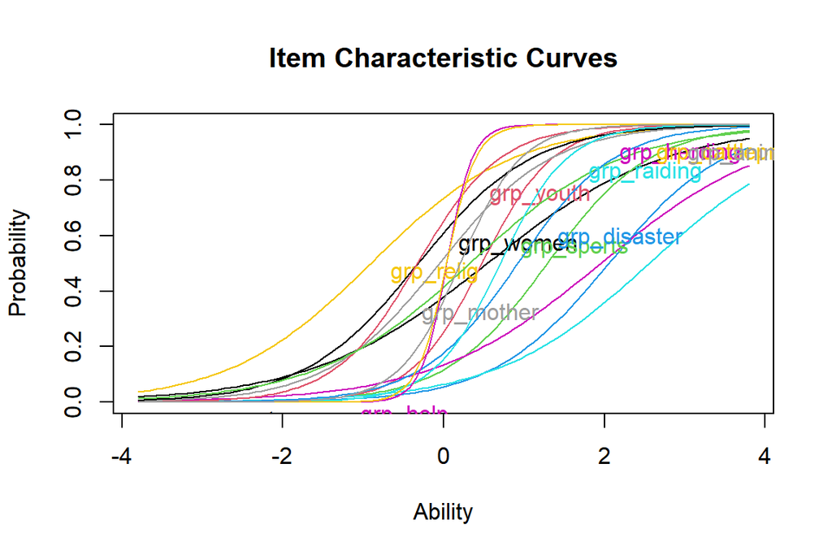

```r
plot(ltm_grps, type="ICC")
```

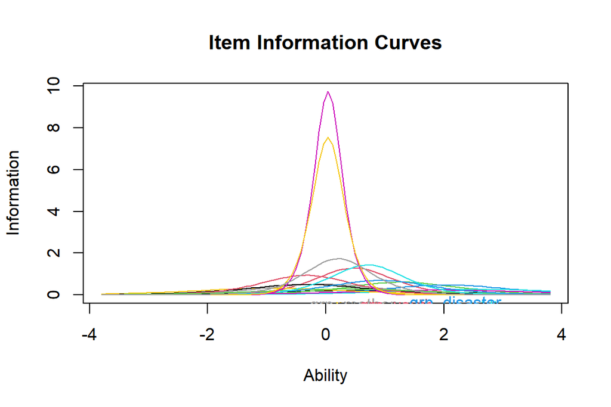

```r
plot(ltm_grps, type="IIC")
```

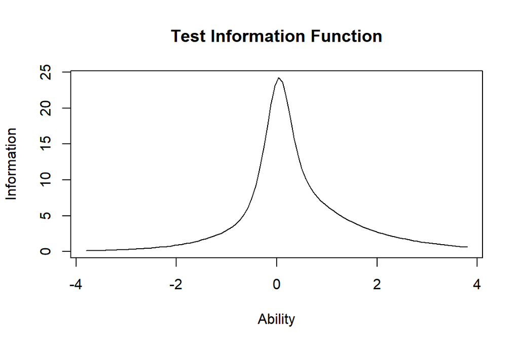

```r
plot(ltm_grps, type="IIC",
     items=0)
```

```r
ltm_grps_out <- coef(ltm_grps) %>%
  as.data.frame() %>%
  rownames_to_column("variable") %>%
  mutate(item=grp_items) %>%
  select(1,4, difficulty=2,discrimination=3)

ltm_grps_out
```

Table 2.3:

| variable | item | difficulty | discrimination |
| --- | --- | --- | --- |
| grp_water | q501a | 0.54 | 0.908 |
| grp_land | q501b | 0.477 | 2.27 |
| grp_resource | q501c | 1.29 | 1.56 |
| grp_credit | q501d | 2.05 | 1.38 |
| grp_savings | q501e | 2.55 | 1.05 |
| grp_help | q501f | 1.95 | 0.951 |
| grp_relig | q501g | -0.907 | 1.13 |
| grp_mother | q501h | -0.0542 | 1.43 |
| grp_women | q501i | -0.318 | 1.41 |
| grp_youth | q501j | -0.328 | 1.94 |
| grp_sports | q501k | 0.324 | 1.05 |
| grp_disaster | q501l | 0.921 | 1.66 |
| grp_raiding | q501m | 0.705 | 2.4 |
| grp_herding | q501n | 0.0382 | 6.24 |
| grp_cattleprotect | q501o | 0.0358 | 5.49 |
| grp_animalherding | q501p | 0.205 | 2.64 |

```r
write_csv(ltm_grps_out, here("output/tables/resilience/grps irt.csv"))

ltm_grps_gt <- ltm_grps_out %>%
  gt() %>%
  fmt_number(3:4,
             decimals=2)

ltm_grps_gt
```

| variable | item | difficulty | discrimination |
| --- | --- | --- | --- |
| grp_water | q501a | 0.54 | 0.91 |
| grp_land | q501b | 0.48 | 2.27 |
| grp_resource | q501c | 1.29 | 1.56 |
| grp_credit | q501d | 2.05 | 1.38 |
| grp_savings | q501e | 2.55 | 1.05 |
| grp_help | q501f | 1.95 | 0.95 |
| grp_relig | q501g | −0.91 | 1.13 |
| grp_mother | q501h | −0.05 | 1.43 |
| grp_women | q501i | −0.32 | 1.41 |
| grp_youth | q501j | −0.33 | 1.94 |
| grp_sports | q501k | 0.32 | 1.05 |
| grp_disaster | q501l | 0.92 | 1.66 |
| grp_raiding | q501m | 0.71 | 2.40 |
| grp_herding | q501n | 0.04 | 6.24 |
| grp_cattleprotect | q501o | 0.04 | 5.49 |
| grp_animalherding | q501p | 0.21 | 2.64 |

```r
gtsave(ltm_grps_gt, here("output/tables/resilience/grps irt.rtf"))
```

#### 2.1.1.3 Factor analysis

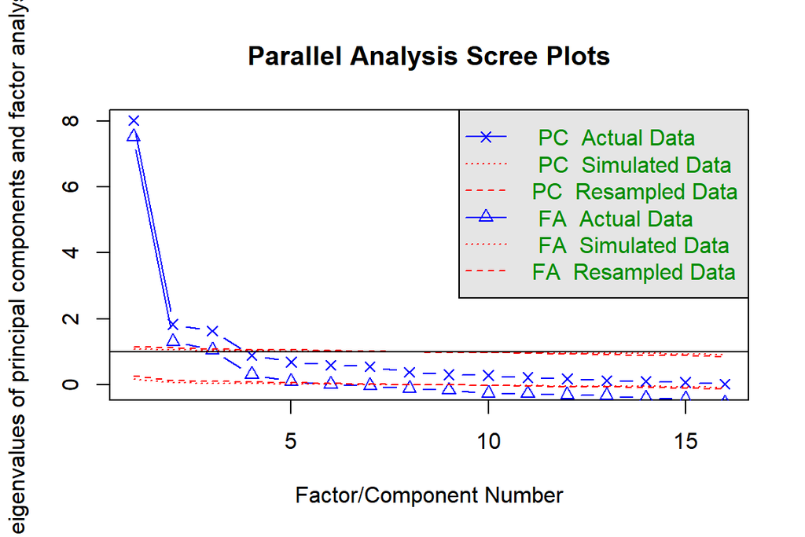

```
## Parallel analysis suggests that the number of factors =  5  and the number of components =  3
```

```r
fa.parallel(grps,
            cor="tet")
```

```r
# 5 factors, 3 components
```

```r
fa_grps_5 <- fa(grps,
                 nfactors=5,
                 scores="tenBerge",
                 fm="ml",
                 cor="tet")
```

```r
fa_grps_5
```

```
## Factor Analysis using method =  ml
## Call: fa(r = grps, nfactors = 5, scores = "tenBerge", fm = "ml", cor = "tet")
## Standardized loadings (pattern matrix) based upon correlation matrix
##                     ML3   ML4   ML2   ML1   ML5   h2    u2 com
## grp_water          0.02  0.08  0.20  0.08  0.40 0.38 0.616 1.7
## grp_land           0.56 -0.01  0.01  0.07  0.35 0.68 0.322 1.7
## grp_resource       0.02  0.04  0.02  0.03  0.91 0.91 0.088 1.0
## grp_credit         0.19 -0.09  0.66  0.06  0.17 0.69 0.308 1.4
## grp_savings       -0.02  0.03  1.00  0.02 -0.03 1.00 0.005 1.0
## grp_help          -0.06  0.16  0.35 -0.11  0.43 0.48 0.521 2.4
## grp_relig          0.09  0.51  0.09  0.22 -0.10 0.48 0.520 1.6
## grp_mother         0.01  0.88 -0.04 -0.02  0.10 0.83 0.169 1.0
## grp_women          0.00  0.97  0.04  0.00 -0.03 0.92 0.077 1.0
## grp_youth          0.27  0.39 -0.08  0.42  0.05 0.74 0.258 2.8
## grp_sports        -0.04  0.02  0.05  0.98  0.01 1.00 0.005 1.0
## grp_disaster       0.34  0.05  0.01  0.37  0.21 0.55 0.454 2.6
## grp_raiding        0.86 -0.05 -0.02  0.07  0.01 0.74 0.257 1.0
## grp_herding        0.99  0.05  0.01 -0.07 -0.01 0.98 0.022 1.0
## grp_cattleprotect  0.99  0.01  0.02 -0.07  0.02 0.96 0.036 1.0
## grp_animalherding  0.76  0.04  0.06  0.17 -0.07 0.72 0.278 1.1
##
##                        ML3  ML4  ML2  ML1  ML5
## SS loadings           4.21 2.49 1.87 1.71 1.79
## Proportion Var        0.26 0.16 0.12 0.11 0.11
## Cumulative Var        0.26 0.42 0.54 0.64 0.75
## Proportion Explained  0.35 0.21 0.16 0.14 0.15
## Cumulative Proportion 0.35 0.56 0.71 0.85 1.00
##
##  With factor correlations of
##      ML3  ML4  ML2  ML1  ML5
## ML3 1.00 0.47 0.27 0.38 0.52
## ML4 0.47 1.00 0.29 0.52 0.43
## ML2 0.27 0.29 1.00 0.36 0.52
## ML1 0.38 0.52 0.36 1.00 0.24
## ML5 0.52 0.43 0.52 0.24 1.00
##
## Mean item complexity =  1.5
## Test of the hypothesis that 5 factors are sufficient.
##
## The degrees of freedom for the null model are  120  and the objective function was  15.2 with Chi Square of  119738
## The degrees of freedom for the model are 50  and the objective function was  0.92
##
## The root mean square of the residuals (RMSR) is  0.03
## The df corrected root mean square of the residuals is  0.04
##
## The harmonic number of observations is  7792 with the empirical chi square  1485  with prob <  4.2e-278
## The total number of observations was  7872  with Likelihood Chi Square =  7241  with prob <  0
##
## Tucker Lewis Index of factoring reliability =  0.856
## RMSEA index =  0.135  and the 90 % confidence intervals are  0.133 0.138
## BIC =  6792
## Fit based upon off diagonal values = 1
## Measures of factor score adequacy
##                                                    ML3  ML4  ML2  ML1  ML5
## Correlation of (regression) scores with factors   0.99 0.97 1.00 1.00 0.96
## Multiple R square of scores with factors          0.99 0.95 0.99 0.99 0.92
## Minimum correlation of possible factor scores     0.97 0.90 0.99 0.99 0.84
```

ML3: cattle herding, cattle protection, cattle raiding, animal herding, land

ML4: women group, mothers group, religious group

ML2: savings group, credit group

ML1: sports, youth

ML5: natural resource management, self-help, water, land management

Captures 75 percent of the variance of all items

Fit statistics good but not great (Tucker-Lewis 86 percent, RMSEA .14)

```r
fa_grps_ldngs <- fa_grps_5$loadings %>%
  unclass() %>%
  as.data.frame() %>%
  rownames_to_column("item") %>%
  mutate(group=grp_labs,
         difficulty=ltm_grps_out$difficulty,
         discrimination=ltm_grps_out$discrimination) %>%
  relocate(group, .after=item)

fa_grps_ldngs
```

Table 2.4:

| item | group | ML3 | ML4 | ML2 | ML1 | ML5 | difficulty | discrimination |
| --- | --- | --- | --- | --- | --- | --- | --- | --- |
| grp_water | Water users | 0.0227 | 0.0833 | 0.204 | 0.0789 | 0.396 | 0.54 | 0.908 |
| grp_land | Grazing land users | 0.557 | -0.00941 | 0.0101 | 0.0669 | 0.35 | 0.477 | 2.27 |
| grp_resource | Community natural resources | 0.0216 | 0.0411 | 0.0211 | 0.0281 | 0.906 | 1.29 | 1.56 |
| grp_credit | Credit/microfinance | 0.187 | -0.0929 | 0.656 | 0.0562 | 0.172 | 2.05 | 1.38 |
| grp_savings | Savings | -0.0246 | 0.0343 | 1 | 0.019 | -0.0301 | 2.55 | 1.05 |
| grp_help | Mutual help | -0.0625 | 0.157 | 0.35 | -0.109 | 0.427 | 1.95 | 0.951 |
| grp_relig | Religious | 0.0858 | 0.512 | 0.0873 | 0.219 | -0.0951 | -0.907 | 1.13 |
| grp_mother | Mothers | 0.00955 | 0.878 | -0.0351 | -0.0195 | 0.104 | -0.0542 | 1.43 |
| grp_women | Women | -0.00481 | 0.966 | 0.0385 | -0.00334 | -0.0302 | -0.318 | 1.41 |
| grp_youth | Youth | 0.265 | 0.394 | -0.0843 | 0.416 | 0.0548 | -0.328 | 1.94 |
| grp_sports | Sports | -0.0391 | 0.017 | 0.0515 | 0.98 | 0.0111 | 0.324 | 1.05 |
| grp_disaster | Disaster planning | 0.338 | 0.0452 | 0.0142 | 0.367 | 0.206 | 0.921 | 1.66 |
| grp_raiding | Cattle raiding | 0.862 | -0.0527 | -0.0236 | 0.0673 | 0.00652 | 0.705 | 2.4 |
| grp_herding | Cattle herding | 0.992 | 0.052 | 0.00558 | -0.0705 | -0.00769 | 0.0382 | 6.24 |
| grp_cattleprotect | Cattle protection | 0.987 | 0.0125 | 0.0217 | -0.0711 | 0.0158 | 0.0358 | 5.49 |
| grp_animalherding | Small animal herding | 0.762 | 0.0424 | 0.06 | 0.166 | -0.0653 | 0.205 | 2.64 |

```r
write_csv(fa_grps_ldngs, here("output/tables/resilience/groups loadings.csv"))

fa_grps_gt <- fa_grps_ldngs %>%
  gt() %>%
  fmt_number(3:9, decimals=2)

fa_grps_gt
```

| item | group | ML3 | ML4 | ML2 | ML1 | ML5 | difficulty | discrimination |
| --- | --- | --- | --- | --- | --- | --- | --- | --- |
| grp_water | Water users | 0.02 | 0.08 | 0.20 | 0.08 | 0.40 | 0.54 | 0.91 |
| grp_land | Grazing land users | 0.56 | −0.01 | 0.01 | 0.07 | 0.35 | 0.48 | 2.27 |
| grp_resource | Community natural resources | 0.02 | 0.04 | 0.02 | 0.03 | 0.91 | 1.29 | 1.56 |
| grp_credit | Credit/microfinance | 0.19 | −0.09 | 0.66 | 0.06 | 0.17 | 2.05 | 1.38 |
| grp_savings | Savings | −0.02 | 0.03 | 1.00 | 0.02 | −0.03 | 2.55 | 1.05 |
| grp_help | Mutual help | −0.06 | 0.16 | 0.35 | −0.11 | 0.43 | 1.95 | 0.95 |
| grp_relig | Religious | 0.09 | 0.51 | 0.09 | 0.22 | −0.10 | −0.91 | 1.13 |
| grp_mother | Mothers | 0.01 | 0.88 | −0.04 | −0.02 | 0.10 | −0.05 | 1.43 |
| grp_women | Women | 0.00 | 0.97 | 0.04 | 0.00 | −0.03 | −0.32 | 1.41 |
| grp_youth | Youth | 0.27 | 0.39 | −0.08 | 0.42 | 0.05 | −0.33 | 1.94 |
| grp_sports | Sports | −0.04 | 0.02 | 0.05 | 0.98 | 0.01 | 0.32 | 1.05 |
| grp_disaster | Disaster planning | 0.34 | 0.05 | 0.01 | 0.37 | 0.21 | 0.92 | 1.66 |
| grp_raiding | Cattle raiding | 0.86 | −0.05 | −0.02 | 0.07 | 0.01 | 0.71 | 2.40 |
| grp_herding | Cattle herding | 0.99 | 0.05 | 0.01 | −0.07 | −0.01 | 0.04 | 6.24 |
| grp_cattleprotect | Cattle protection | 0.99 | 0.01 | 0.02 | −0.07 | 0.02 | 0.04 | 5.49 |
| grp_animalherding | Small animal herding | 0.76 | 0.04 | 0.06 | 0.17 | −0.07 | 0.21 | 2.64 |

```r
gtsave(fa_grps_gt, here("output/tables/resilience/groups loadings.rtf"))
```

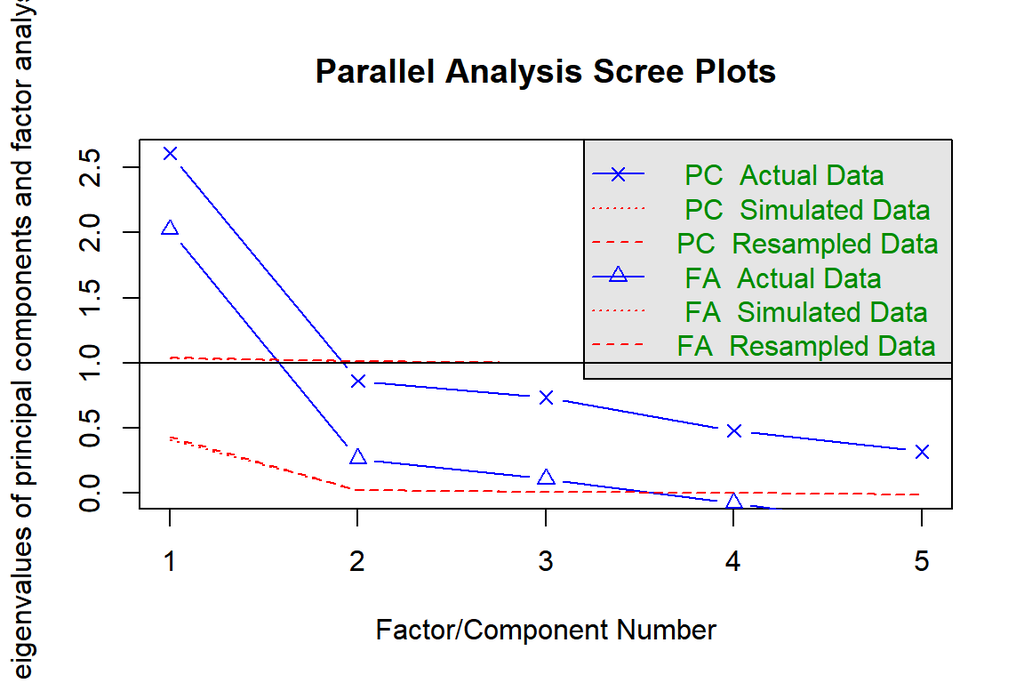

```
## Parallel analysis suggests that the number of factors =  3  and the number of components =  1
```

```r
fa_grps_5_scrs <- fa_grps_5$scores %>%
  as.data.frame()

dat <- dat %>%
  mutate(grp_fac_cattle = fa_grps_5_scrs$ML3,
         grp_fac_women = fa_grps_5_scrs$ML4,
         grp_fac_finance = fa_grps_5_scrs$ML2,
         grp_fac_sports = fa_grps_5_scrs$ML1,
         grp_fac_nature = fa_grps_5_scrs$ML5)

grp_facs <- dat %>%
  select(grp_fac_cattle:grp_fac_nature)

fa.parallel(grp_facs)
```

Three factors and one component. We are interested in a single broad measure of group membership, so we will extract a single factor.

```r
fa_grp_fac <-fa(grp_facs,
                 scores="tenBerge",
                 fm="ml")

fa_grp_fac
```

```
## Factor Analysis using method =  ml
## Call: fa(r = grp_facs, scores = "tenBerge", fm = "ml")
## Standardized loadings (pattern matrix) based upon correlation matrix
##                  ML1   h2   u2 com
## grp_fac_cattle  0.67 0.45 0.55   1
## grp_fac_women   0.68 0.47 0.53   1
## grp_fac_finance 0.55 0.30 0.70   1
## grp_fac_sports  0.57 0.33 0.67   1
## grp_fac_nature  0.69 0.47 0.53   1
##
##                 ML1
## SS loadings    2.03
## Proportion Var 0.41
##
## Mean item complexity =  1
## Test of the hypothesis that 1 factor is sufficient.
##
## The degrees of freedom for the null model are  10  and the objective function was  1.39 with Chi Square of  10928
## The degrees of freedom for the model are 5  and the objective function was  0.27
##
## The root mean square of the residuals (RMSR) is  0.09
## The df corrected root mean square of the residuals is  0.13
##
## The harmonic number of observations is  7656 with the empirical chi square  1278  with prob <  3e-274
## The total number of observations was  7872  with Likelihood Chi Square =  2088  with prob <  0
##
## Tucker Lewis Index of factoring reliability =  0.618
## RMSEA index =  0.23  and the 90 % confidence intervals are  0.222 0.238
## BIC =  2043
## Fit based upon off diagonal values = 0.95
## Measures of factor score adequacy
##                                                    ML1
## Correlation of (regression) scores with factors   0.88
## Multiple R square of scores with factors          0.78
## Minimum correlation of possible factor scores     0.56
```

```r
fa_grp_fac_ldngs <- fa_grp_fac$loadings %>%
  unclass() %>%
  as.data.frame() %>%
  rownames_to_column("item") %>%
  mutate(description=c("Cattle/herding","Women/Mothers","Savings/Credit","Sports/Youth","Natural resource management")) %>%
  relocate(description, .after=item)

fa_grp_fac_ldngs
```

Table 2.5:

| item | description | ML1 |
| --- | --- | --- |
| grp_fac_cattle | Cattle/herding | 0.673 |
| grp_fac_women | Women/Mothers | 0.683 |
| grp_fac_finance | Savings/Credit | 0.552 |
| grp_fac_sports | Sports/Youth | 0.571 |
| grp_fac_nature | Natural resource management | 0.689 |

```r
write_csv(fa_grp_fac_ldngs, here("output/tables/resilience/group facs loadings.csv"))

fa_grp_fac_gt <- fa_grp_fac_ldngs %>%
  gt() %>%
  fmt_number(3, decimals=2)

fa_grp_fac_gt
```

| item | description | ML1 |
| --- | --- | --- |
| grp_fac_cattle | Cattle/herding | 0.67 |
| grp_fac_women | Women/Mothers | 0.68 |
| grp_fac_finance | Savings/Credit | 0.55 |
| grp_fac_sports | Sports/Youth | 0.57 |
| grp_fac_nature | Natural resource management | 0.69 |

```r
gtsave(fa_grp_fac_gt, here("output/tables/resilience/group facs loadings.rtf"))
```

```r
fa_grp_fac_scrs <- fa_grp_fac$scores %>%
  unlist() %>%
  as.data.frame()

dat <- dat %>%
  mutate(grp_latent = fa_grp_fac_scrs$ML1,
         grp_latent_resc = scales::rescale(grp_latent, c(0,100)))
#class(dat$grp_latent_resc)
```

```r
grp_latent_mn <- svyrdat %>%
  summarize(grp = survey_mean(grp_latent_resc, na.rm=T)) %>%
  mutate(lower=grp-1.96*grp_se,
         upper=grp+1.96*grp_se)

grp_latent_mn
```

Table 2.6:

| grp | grp_se | lower | upper |
| --- | --- | --- | --- |
| 35.2 | 1.09 | 33.1 | 37.4 |

### 2.1.2 Remittances

```r
remit_mn <- svyrdat %>%
  summarize(remit = survey_mean(access_remittances, na.rm=T)) %>%
  mutate(lower=remit-1.96*remit_se,
         upper=remit+1.96*remit_se)

remit_mn
```

Table 2.7:

| remit | remit_se | lower | upper |
| --- | --- | --- | --- |
| 0.0565 | 0.00535 | 0.046 | 0.067 |

```r
prin_grp_facs <- principal(grp_facs)
prin_grp_facs
```

```
## Principal Components Analysis
## Call: principal(r = grp_facs)
## Standardized loadings (pattern matrix) based upon correlation matrix
##                  PC1   h2   u2 com
## grp_fac_cattle  0.74 0.55 0.45   1
## grp_fac_women   0.76 0.58 0.42   1
## grp_fac_finance 0.67 0.44 0.56   1
## grp_fac_sports  0.68 0.47 0.53   1
## grp_fac_nature  0.76 0.58 0.42   1
##
##                 PC1
## SS loadings    2.61
## Proportion Var 0.52
##
## Mean item complexity =  1
## Test of the hypothesis that 1 component is sufficient.
##
## The root mean square of the residuals (RMSR) is  0.15
##  with the empirical chi square  3555  with prob <  0
##
## Fit based upon off diagonal values = 0.87
```

```r
prin_grp_facs_scrs <- data.frame(prin_grp_facs$scores)
describe(prin_grp_facs_scrs)
```

Table 2.8:

| vars | n | mean | sd | median | trimmed | mad | min | max | range | skew | kurtosis | se |
| --- | --- | --- | --- | --- | --- | --- | --- | --- | --- | --- | --- | --- |
| 1 | 7.66e+03 | 1.91e-17 | 1 | -0.112 | -0.0846 | 1.03 | -1.38 | 2.87 | 4.25 | 0.74 | 0.212 | 0.0114 |

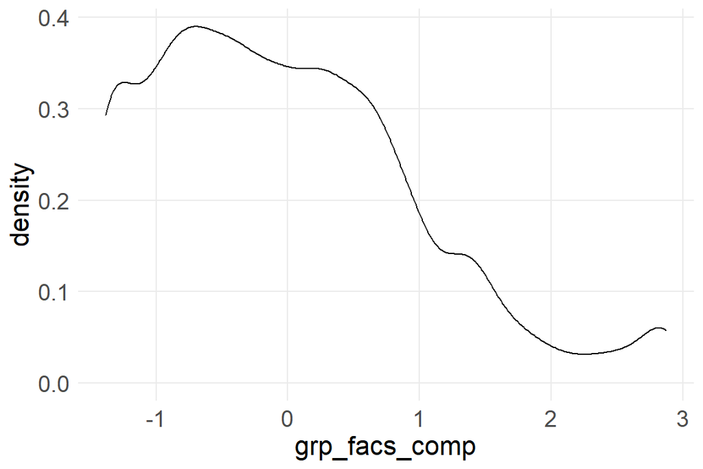

```r
dat <- dat %>%
  mutate(grp_facs_comp=prin_grp_facs_scrs$PC1)

ggplot(dat, aes(grp_facs_comp)) +
  geom_density()
```

```r
prin_grps <- principal(grps,
                       cor="tet")
```

```r
prin_grps
```

```
## Principal Components Analysis
## Call: principal(r = grps, cor = "tet")
## Standardized loadings (pattern matrix) based upon correlation matrix
##                    PC1   h2   u2 com
## grp_water         0.57 0.33 0.67   1
## grp_land          0.79 0.63 0.37   1
## grp_resource      0.73 0.53 0.47   1
## grp_credit        0.65 0.42 0.58   1
## grp_savings       0.56 0.31 0.69   1
## grp_help          0.55 0.30 0.70   1
## grp_relig         0.61 0.37 0.63   1
## grp_mother        0.71 0.51 0.49   1
## grp_women         0.70 0.50 0.50   1
## grp_youth         0.79 0.62 0.38   1
## grp_sports        0.63 0.40 0.60   1
## grp_disaster      0.74 0.55 0.45   1
## grp_raiding       0.75 0.57 0.43   1
## grp_herding       0.82 0.68 0.32   1
## grp_cattleprotect 0.82 0.67 0.33   1
## grp_animalherding 0.79 0.63 0.37   1
##
##                 PC1
## SS loadings    8.01
## Proportion Var 0.50
##
## Mean item complexity =  1
## Test of the hypothesis that 1 component is sufficient.
##
## The root mean square of the residuals (RMSR) is  0.13
##  with the empirical chi square  33443  with prob <  0
##
## Fit based upon off diagonal values = 0.92
```

```r
prin_grps_scrs <- data.frame(prin_grps$scores)
describe(prin_grps_scrs)
```

Table 2.9:

| vars | n | mean | sd | median | trimmed | mad | min | max | range | skew | kurtosis | se |
| --- | --- | --- | --- | --- | --- | --- | --- | --- | --- | --- | --- | --- |
| 1 | 7.66e+03 | -0.00218 | 0.813 | -0.0923 | -0.0484 | 0.919 | -1.18 | 2 | 3.17 | 0.43 | -0.652 | 0.0093 |

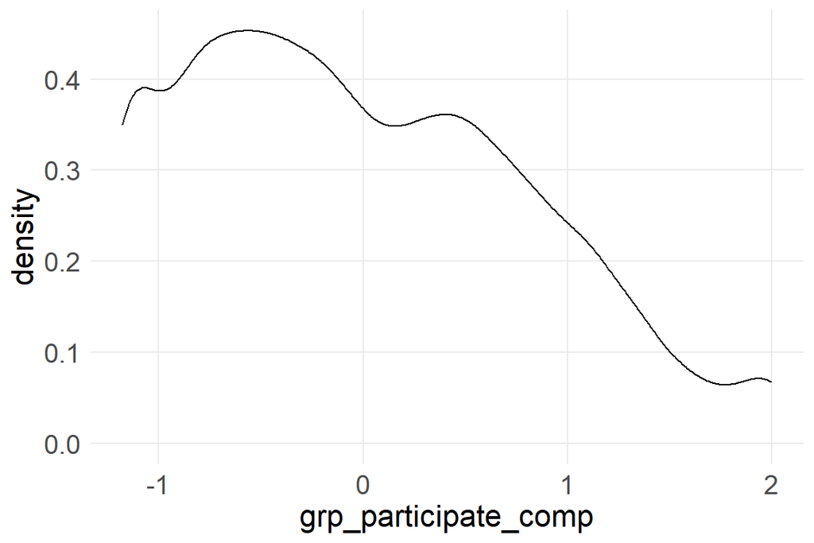

```r
dat <- dat %>%
  mutate(grp_participate_comp=prin_grps_scrs$PC1)

ggplot(dat, aes(grp_participate_comp)) +
  geom_density()
```

```r
g1 <- svyglm(fies_raw ~ grp_participate_comp + shock_exposure_index +
               as.factor(county),
             design=svydat)
```

[output not shown]

```r
summary(g1)
```

[output not shown]

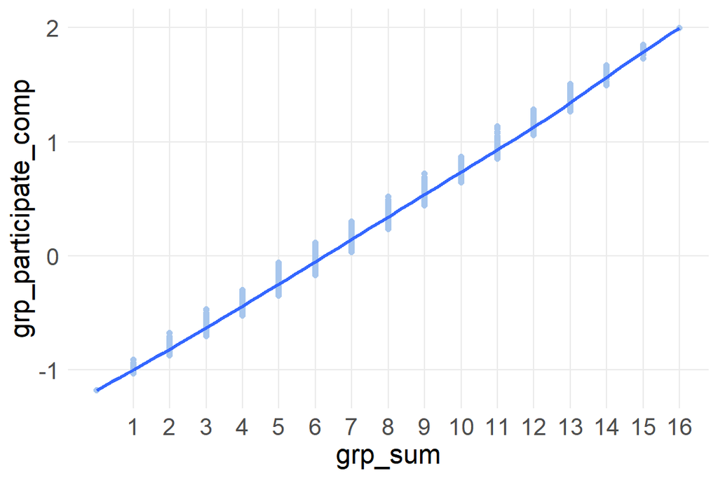

```r
ggplot(dat, aes(grp_sum, grp_participate_comp)) +
  geom_point(color=light_blue) +
  stat_smooth() +
  scale_x_continuous(breaks=1:16)
```

### 2.1.3 Bonding social capital

```r
frq(dat$bonding_capital_raw)
```

```
## Bonding Capital Raw Score (x) <numeric>
## # total N=7872 valid N=7811 mean=1.65 sd=1.63
##
## Value |    N | Raw % | Valid % | Cum. %
## ---------------------------------------
##     0 | 3227 | 40.99 |   41.31 |  41.31
##     1 |  581 |  7.38 |    7.44 |  48.75
##     2 | 1721 | 21.86 |   22.03 |  70.78
##     3 |  264 |  3.35 |    3.38 |  74.16
##     4 | 2018 | 25.64 |   25.84 | 100.00
##  <NA> |   61 |  0.77 |    <NA> |   <NA>
```

```r
bond <- dat %>%
  select(q_490,
         rc_q_491,
         q_494,
         rc_q_495)

map(bond, frq)
```

```
## $q_490
## Q 490: Will your household be able to lean on relatives living in your community (x) <numeric>
## # total N=7872 valid N=7824 mean=0.53 sd=0.50
##
## Value |      Label |    N | Raw % | Valid % | Cum. %
## ----------------------------------------------------
##     0 |         No | 3651 | 46.38 |   46.66 |  46.66
##     1 |        Yes | 4173 | 53.01 |   53.34 | 100.00
##     8 | Don't know |    0 |  0.00 |    0.00 | 100.00
##     9 |    Refused |    0 |  0.00 |    0.00 | 100.00
##  <NA> |       <NA> |   48 |  0.61 |    <NA> |   <NA>
##
## $rc_q_491
## Q491: Recode for bonding social capital sub-index (x) <numeric>
## # total N=7872 valid N=7824 mean=0.42 sd=0.49
##
## Value |    N | Raw % | Valid % | Cum. %
## ---------------------------------------
##     0 | 4542 | 57.70 |   58.05 |  58.05
##     1 | 3282 | 41.69 |   41.95 | 100.00
##  <NA> |   48 |  0.61 |    <NA> |   <NA>
##
## $q_494
## Q 494: Will your household be able to lean on non-relatives living in your commu (x) <numeric>
## # total N=7872 valid N=7820 mean=0.39 sd=0.49
##
## Value |      Label |    N | Raw % | Valid % | Cum. %
## ----------------------------------------------------
##     0 |         No | 4764 | 60.52 |   60.92 |  60.92
##     1 |        Yes | 3056 | 38.82 |   39.08 | 100.00
##     8 | Don't know |    0 |  0.00 |    0.00 | 100.00
##     9 |    Refused |    0 |  0.00 |    0.00 | 100.00
##  <NA> |       <NA> |   52 |  0.66 |    <NA> |   <NA>
##
## $rc_q_495
## Q495: Recode for bonding social capital sub-index (x) <numeric>
## # total N=7872 valid N=7820 mean=0.31 sd=0.46
##
## Value |    N | Raw % | Valid % | Cum. %
## ---------------------------------------
##     0 | 5428 | 68.95 |   69.41 |  69.41
##     1 | 2392 | 30.39 |   30.59 | 100.00
##  <NA> |   52 |  0.66 |    <NA> |   <NA>
```

```r
irt_bond <- ltm(bond ~ z1)

irt_bond
```

```
##
## Call:
## ltm(formula = bond ~ z1)
##
## Coefficients:
##           Dffclt  Dscrmn
## q_490     -0.091   14.94
## rc_q_491   0.021    6.65
## q_494      0.023   21.40
## rc_q_495   0.126   14.73
##
## Log.Lik: -14216
```

```r
#summary(l1)
```

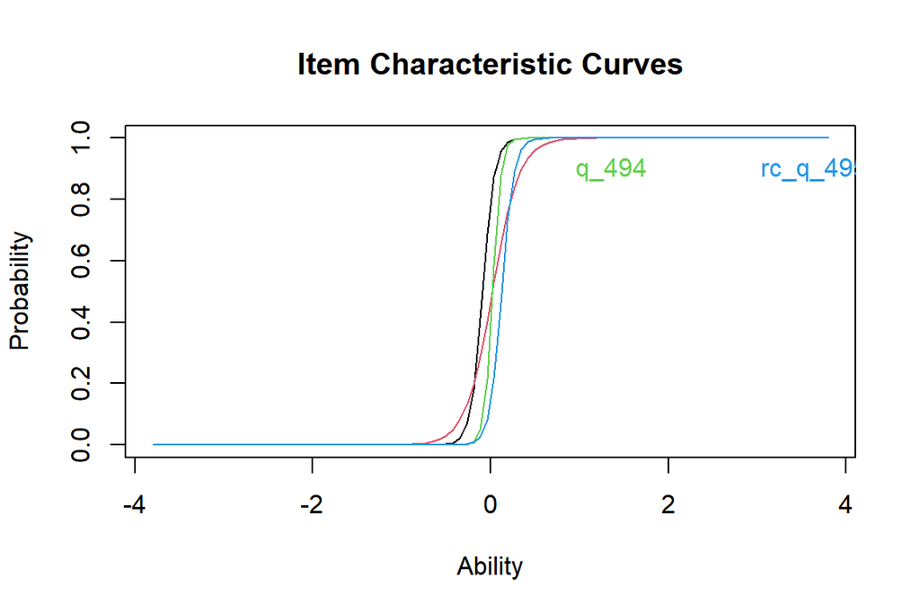

```r
plot(irt_bond, type="ICC")
```

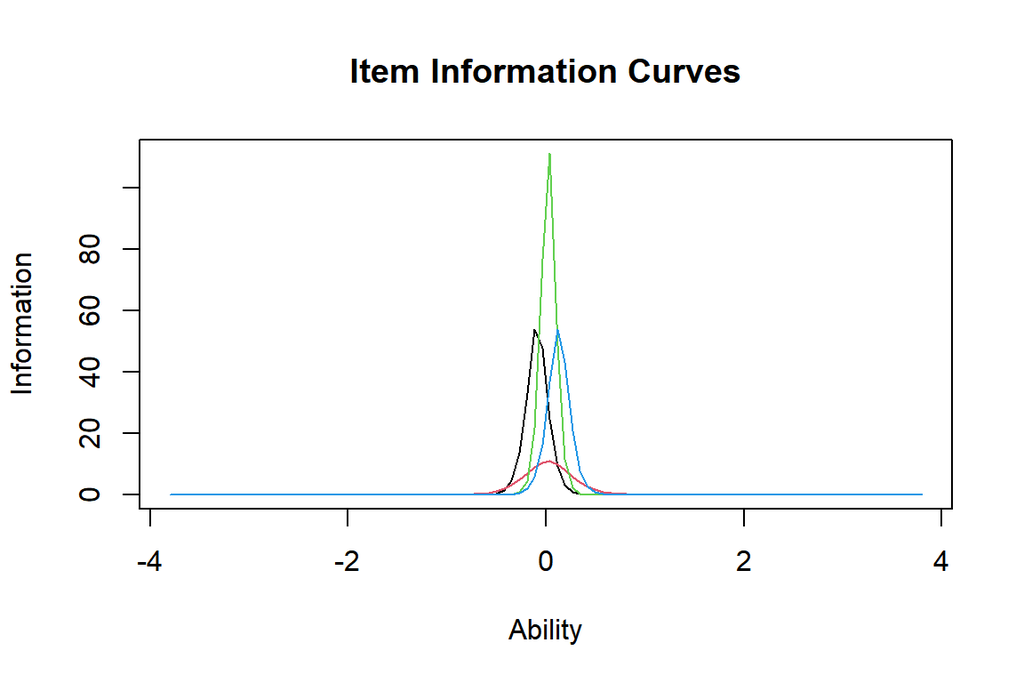

```r
plot(irt_bond, type="IIC")
```

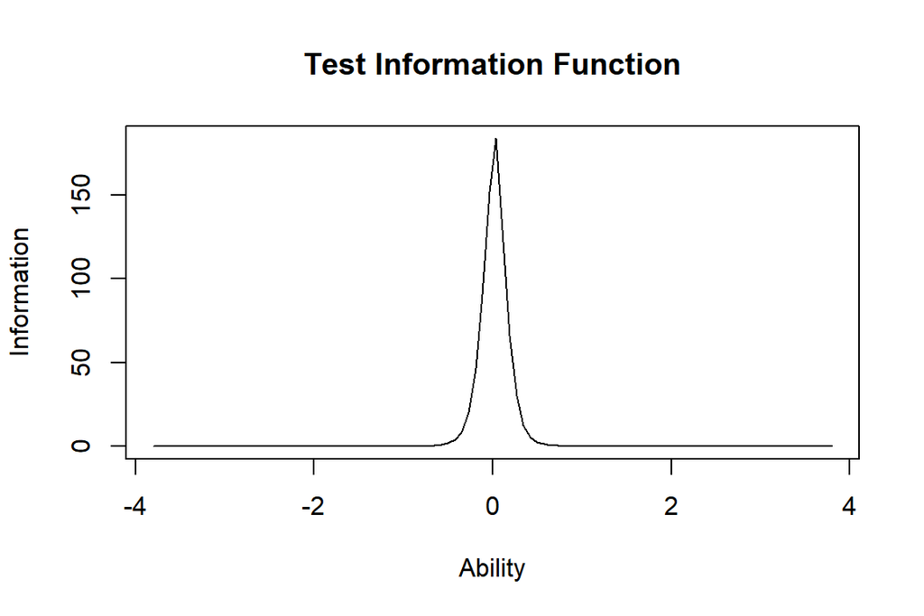

```r
plot(irt_bond,
     type="IIC",
     items=0)
```

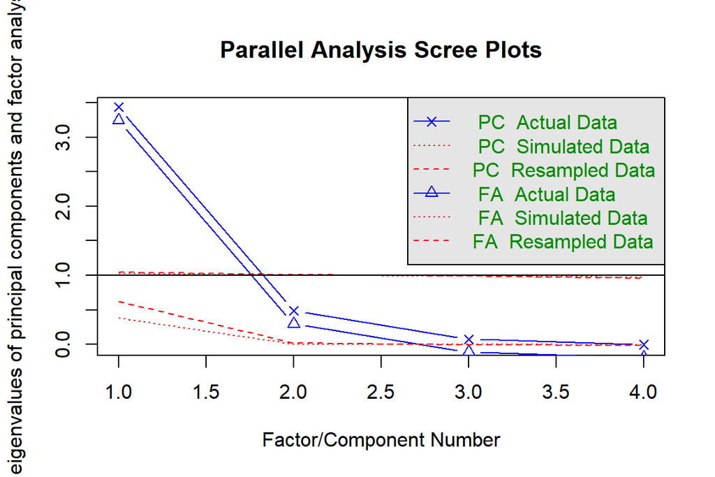

```
## Parallel analysis suggests that the number of factors =  2  and the number of components =  1
```

```r
fa.parallel(bond,
            cor="tet")
```

```r
# 2 factors, 1 components

fa_bond_2 <- fa(bond,
                nfactors=2,
                scores="tenBerge",
                fm="ml",
                cor="tet")
```

```r
fa_bond_2
```

```
## Factor Analysis using method =  ml
## Call: fa(r = bond, nfactors = 2, scores = "tenBerge", fm = "ml", cor = "tet")
## Standardized loadings (pattern matrix) based upon correlation matrix
##            ML2   ML1   h2     u2 com
## q_490    -0.05  1.03 1.00 0.0050   1
## rc_q_491  0.08  0.90 0.93 0.0670   1
## q_494     0.94  0.02 0.93 0.0739   1
## rc_q_495  1.01 -0.01 1.00 0.0049   1
##
##                        ML2  ML1
## SS loadings           1.94 1.91
## Proportion Var        0.49 0.48
## Cumulative Var        0.49 0.96
## Proportion Explained  0.50 0.50
## Cumulative Proportion 0.50 1.00
##
##  With factor correlations of
##      ML2  ML1
## ML2 1.00 0.77
## ML1 0.77 1.00
##
## Mean item complexity =  1
## Test of the hypothesis that 2 factors are sufficient.
##
## The degrees of freedom for the null model are  6  and the objective function was  25.1 with Chi Square of  197441
## The degrees of freedom for the model are -1  and the objective function was  19.1
##
## The root mean square of the residuals (RMSR) is  0.03
## The df corrected root mean square of the residuals is  NA
##
## The harmonic number of observations is  7816 with the empirical chi square  68.2  with prob <  NA
## The total number of observations was  7872  with Likelihood Chi Square =  150056  with prob <  NA
##
## Tucker Lewis Index of factoring reliability =  5.56
## Fit based upon off diagonal values = 1
## Measures of factor score adequacy
##                                                    ML2  ML1
## Correlation of (regression) scores with factors   1.00 1.00
## Multiple R square of scores with factors          1.00 1.00
## Minimum correlation of possible factor scores     0.99 0.99
```

```r
fa_bond_1 <- fa(bond,
                nfactors=1,
                #scores="tenBerge",
                fm="ml",
                cor="tet")
```

```r
fa_bond_1
```

```
## Factor Analysis using method =  ml
## Call: fa(r = bond, nfactors = 1, fm = "ml", cor = "tet")
## Standardized loadings (pattern matrix) based upon correlation matrix
##           ML1   h2    u2 com
## q_490    0.98 0.96 0.040   1
## rc_q_491 0.98 0.96 0.044   1
## q_494    0.75 0.56 0.441   1
## rc_q_495 0.79 0.62 0.379   1
##
##                 ML1
## SS loadings    3.10
## Proportion Var 0.77
##
## Mean item complexity =  1
## Test of the hypothesis that 1 factor is sufficient.
##
## The degrees of freedom for the null model are  6  and the objective function was  25.1 with Chi Square of  197441
## The degrees of freedom for the model are 2  and the objective function was  20.9
##
## The root mean square of the residuals (RMSR) is  0.15
## The df corrected root mean square of the residuals is  0.26
##
## The harmonic number of observations is  7816 with the empirical chi square  2190  with prob <  0
## The total number of observations was  7872  with Likelihood Chi Square =  164173  with prob <  0
##
## Tucker Lewis Index of factoring reliability =  -1.5
## RMSEA index =  3.23  and the 90 % confidence intervals are  3.22 3.24
## BIC =  164155
## Fit based upon off diagonal values = 0.97
## Measures of factor score adequacy
##                                                    ML1
## Correlation of (regression) scores with factors   0.99
## Multiple R square of scores with factors          0.98
## Minimum correlation of possible factor scores     0.96
```

```r
prin_bond <- principal(bond,
                       cor="tet")
```

```r
prin_bond
```

```
## Principal Components Analysis
## Call: principal(r = bond, cor = "tet")
## Standardized loadings (pattern matrix) based upon correlation matrix
##           PC1   h2   u2 com
## q_490    0.93 0.86 0.14   1
## rc_q_491 0.92 0.86 0.14   1
## q_494    0.91 0.84 0.16   1
## rc_q_495 0.94 0.88 0.12   1
##
##                 PC1
## SS loadings    3.43
## Proportion Var 0.86
##
## Mean item complexity =  1
## Test of the hypothesis that 1 component is sufficient.
##
## The root mean square of the residuals (RMSR) is  0.12
##  with the empirical chi square  1294  with prob <  8.8e-282
##
## Fit based upon off diagonal values = 0.98
```

```r
frq(dat$bonding_capital_raw)
```

```
## Bonding Capital Raw Score (x) <numeric>
## # total N=7872 valid N=7811 mean=1.65 sd=1.63
##
## Value |    N | Raw % | Valid % | Cum. %
## ---------------------------------------
##     0 | 3227 | 40.99 |   41.31 |  41.31
##     1 |  581 |  7.38 |    7.44 |  48.75
##     2 | 1721 | 21.86 |   22.03 |  70.78
##     3 |  264 |  3.35 |    3.38 |  74.16
##     4 | 2018 | 25.64 |   25.84 | 100.00
##  <NA> |   61 |  0.77 |    <NA> |   <NA>
```

```r
prin_bond_scrs <- prin_bond$scores %>%
  as.data.frame()

dat <- dat %>%
  mutate(bonding_capital_comp = prin_bond_scrs$PC1)

describe(dat$bonding_capital_comp)
```

Table 2.10:

| vars | n | mean | sd | median | trimmed | mad | min | max | range | skew | kurtosis | se |
| --- | --- | --- | --- | --- | --- | --- | --- | --- | --- | --- | --- | --- |
| 1 | 7.81e+03 | 0.000177 | 0.909 | 0.175 | -0.0499 | 1.61 | -0.913 | 1.31 | 2.23 | 0.376 | -1.44 | 0.0103 |

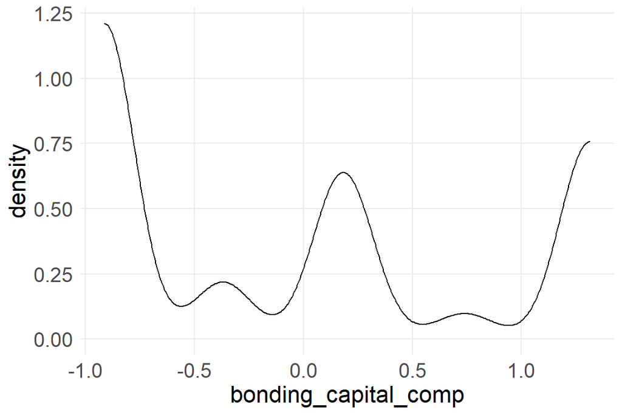

```r
ggplot(dat, aes(bonding_capital_comp)) +
  geom_density()
```

```r
frq(dat$bonding_capital_comp)
```

```
## x <numeric>
## # total N=7872 valid N=7811 mean=0.00 sd=0.91
##
## Value |    N | Raw % | Valid % | Cum. %
## ---------------------------------------
## -0.91 | 3227 | 40.99 |   41.31 |  41.31
## -0.37 |  432 |  5.49 |    5.53 |  46.84
## -0.37 |  149 |  1.89 |    1.91 |  48.75
##  0.17 |  355 |  4.51 |    4.54 |  53.30
##  0.18 | 1100 | 13.97 |   14.08 |  67.38
##  0.23 |  266 |  3.38 |    3.41 |  70.78
##  0.72 |  160 |  2.03 |    2.05 |  72.83
##  0.77 |  104 |  1.32 |    1.33 |  74.16
##  1.31 | 2018 | 25.64 |   25.84 | 100.00
##  <NA> |   61 |  0.77 |    <NA> |   <NA>
```

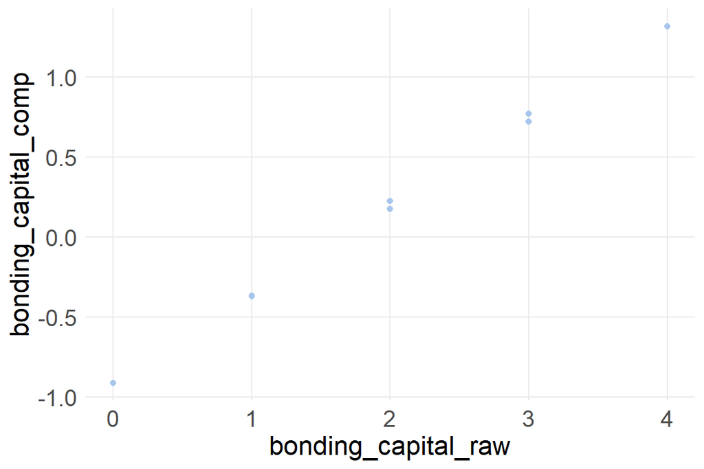

```r
ggplot(dat, aes(bonding_capital_raw, bonding_capital_comp)) +
  geom_point(color=light_blue) +
  stat_smooth()
```

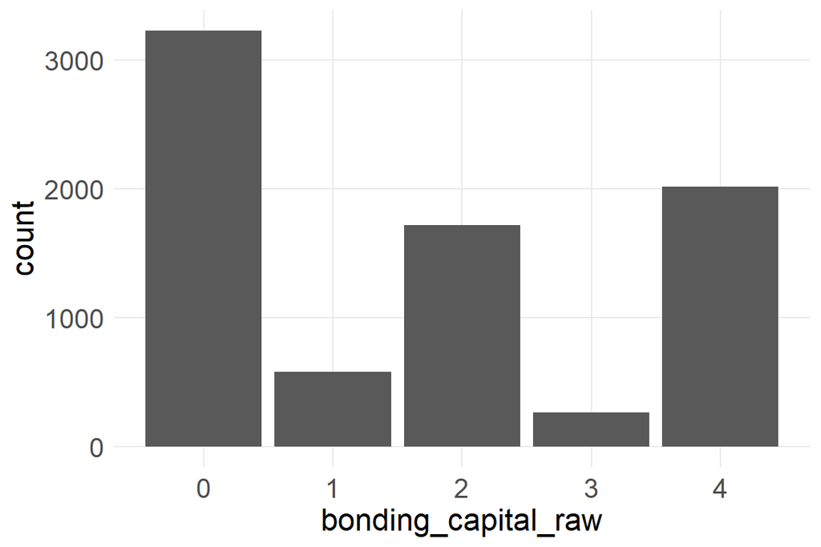

```r
ggplot(dat, aes(bonding_capital_raw)) +
  geom_bar()
```

```r
g2 <- svyglm(fies_raw ~ grp_participate_comp + bonding_capital_comp + shock_exposure_index +
               as.factor(county),
             design=svydat)
```

[output not shown]

```r
summary(g2)
```

[output not shown]

### 2.1.4 Access to savings / remittances

```r
library(sjPlot)

frq(dat$q_401_a)
```

```
## Q 401_a: Sources of household food/income - Own farming/crop production and sale (x) <numeric>
## # total N=7872 valid N=7815 mean=0.56 sd=0.79
##
## Value |      Label |    N | Raw % | Valid % | Cum. %
## ----------------------------------------------------
##     0 |         No | 3759 | 47.75 |   48.10 |  48.10
##     1 |        Yes | 4011 | 50.95 |   51.32 |  99.42
##     8 | Don't know |   17 |  0.22 |    0.22 |  99.64
##     9 |    Refused |   28 |  0.36 |    0.36 | 100.00
##  <NA> |       <NA> |   57 |  0.72 |    <NA> |   <NA>
```

```r
frq(dat$q_401_a_bin)
```

```
## Q 401_a: Sources of HH food/income - Own farming/crop production (binary) (x) <numeric>
## # total N=7872 valid N=7872 mean=0.51 sd=0.50
##
## Value |      Label |    N | Raw % | Valid % | Cum. %
## ----------------------------------------------------
##     0 |         No | 3861 | 49.05 |   49.05 |  49.05
##     1 |        Yes | 4011 | 50.95 |   50.95 | 100.00
##     8 | Don't know |    0 |  0.00 |    0.00 | 100.00
##     9 |    Refused |    0 |  0.00 |    0.00 | 100.00
##  <NA> |       <NA> |    0 |  0.00 |    <NA> |   <NA>
```

```r
inc <- dat %>%
  select(q_401_a_bin,
         q_401_b_bin,
         q_401_c_bin,
         q_401_d_bin,
         q_401_e_bin,
         q_401_f_bin,
         q_401_g_bin,
         q_401_h_bin,
         q_401_i_bin,
         q_401_j_bin,
         q_401_k_bin,
         q_401_l_bin,
         q_401_m_bin,
         q_401_n_bin,
         q_401_o_bin,
         q_401_p_bin,
         q_401_q_bin,
         q_401_r_bin,
         q_401_s_bin,
         q_401_t_bin)

map(inc, frq)
```

```
## $q_401_a_bin
## Q 401_a: Sources of HH food/income - Own farming/crop production (binary) (x) <numeric>
## # total N=7872 valid N=7872 mean=0.51 sd=0.50
##
## Value |      Label |    N | Raw % | Valid % | Cum. %
## ----------------------------------------------------
##     0 |         No | 3861 | 49.05 |   49.05 |  49.05
##     1 |        Yes | 4011 | 50.95 |   50.95 | 100.00
##     8 | Don't know |    0 |  0.00 |    0.00 | 100.00
##     9 |    Refused |    0 |  0.00 |    0.00 | 100.00
##  <NA> |       <NA> |    0 |  0.00 |    <NA> |   <NA>
##
## $q_401_b_bin
## Q 401_b: Sources of HH food/income - Own cattle production (binary) (x) <numeric>
## # total N=7872 valid N=7872 mean=0.42 sd=0.49
##
## Value |      Label |    N | Raw % | Valid % | Cum. %
## ----------------------------------------------------
##     0 |         No | 4558 | 57.90 |   57.90 |  57.90
##     1 |        Yes | 3314 | 42.10 |   42.10 | 100.00
##     8 | Don't know |    0 |  0.00 |    0.00 | 100.00
##     9 |    Refused |    0 |  0.00 |    0.00 | 100.00
##  <NA> |       <NA> |    0 |  0.00 |    <NA> |   <NA>
##
## $q_401_c_bin
## Q 401_c: Sources of HH food/income - Own goats production (binary) (x) <numeric>
## # total N=7872 valid N=7872 mean=0.40 sd=0.49
##
## Value |      Label |    N | Raw % | Valid % | Cum. %
## ----------------------------------------------------
##     0 |         No | 4728 | 60.06 |   60.06 |  60.06
##     1 |        Yes | 3144 | 39.94 |   39.94 | 100.00
##     8 | Don't know |    0 |  0.00 |    0.00 | 100.00
##     9 |    Refused |    0 |  0.00 |    0.00 | 100.00
##  <NA> |       <NA> |    0 |  0.00 |    <NA> |   <NA>
##
## $q_401_d_bin
## Q 401_d: Sources of HH food/income - Own sheep production (binary) (x) <numeric>
## # total N=7872 valid N=7872 mean=0.28 sd=0.45
##
```

[output cut: 184 more lines]

```
##     8 | Don't know |    0 |  0.00 |    0.00 | 100.00
##     9 |    Refused |    0 |  0.00 |    0.00 | 100.00
##  <NA> |       <NA> |    0 |  0.00 |    <NA> |   <NA>
##
## $q_401_t_bin
## Q 401_t: Sources of HH food/income - Safety net food / cash assistance (binary) (x) <numeric>
## # total N=7872 valid N=7872 mean=0.27 sd=0.45
##
## Value |      Label |    N | Raw % | Valid % | Cum. %
## ----------------------------------------------------
##     0 |         No | 5721 | 72.68 |   72.68 |  72.68
##     1 |        Yes | 2151 | 27.32 |   27.32 | 100.00
##     8 | Don't know |    0 |  0.00 |    0.00 | 100.00
##     9 |    Refused |    0 |  0.00 |    0.00 | 100.00
##  <NA> |       <NA> |    0 |  0.00 |    <NA> |   <NA>
```

```r
#sjt.stackfrq(inc)
```

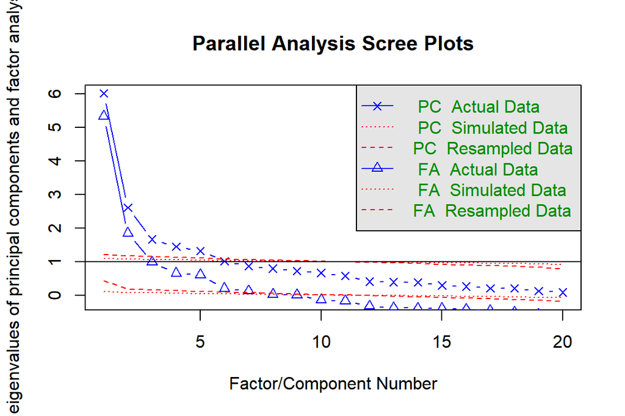

```
## Parallel analysis suggests that the number of factors =  7  and the number of components =  5
```

```r
fa.parallel(inc,
            cor="tet")
```

7 factors, 5 components

#### 2.1.4.1 7 factors

```r
fa_inc_7 <- fa(inc,
               nfactors=7,
               scores="tenBerge",
               fm="ml",
               cor="tet")
```

```r
fa_inc_7
```

```
## Factor Analysis using method =  ml
## Call: fa(r = inc, nfactors = 7, scores = "tenBerge", fm = "ml", cor = "tet")
## Standardized loadings (pattern matrix) based upon correlation matrix
##               ML4   ML5   ML1   ML3   ML6   ML2   ML7   h2    u2 com
## q_401_a_bin  0.02  0.03  0.05  0.00  0.01  0.97 -0.01 1.00 0.005 1.0
## q_401_b_bin  0.73 -0.03 -0.16  0.00 -0.03  0.14  0.12 0.63 0.370 1.2
## q_401_c_bin  0.93 -0.02  0.03 -0.01 -0.03 -0.03 -0.02 0.83 0.165 1.0
## q_401_d_bin  0.93  0.05  0.05  0.02  0.01 -0.01 -0.02 0.90 0.100 1.0
## q_401_e_bin  0.11 -0.10 -0.03  0.07  0.03 -0.03  0.29 0.11 0.891 1.8
## q_401_f_bin  0.03  0.01  0.96 -0.01 -0.01  0.08  0.06 1.00 0.005 1.0
## q_401_g_bin  0.02 -0.02  0.57  0.40  0.20 -0.05 -0.11 0.80 0.198 2.2
## q_401_h_bin -0.07  0.21  0.21  0.42 -0.27 -0.14  0.36 0.63 0.373 4.2
## q_401_i_bin  0.02  0.03  0.01  0.97  0.03  0.02  0.00 1.00 0.005 1.0
## q_401_j_bin -0.11 -0.06 -0.02  0.19  0.56  0.08  0.00 0.38 0.615 1.4
## q_401_k_bin  0.15  0.17  0.20 -0.10  0.00  0.01  0.37 0.32 0.677 2.6
## q_401_l_bin  0.25 -0.04  0.14  0.07  0.13  0.22  0.37 0.47 0.528 3.3
## q_401_m_bin  0.15  0.63  0.19  0.01  0.09 -0.01 -0.23 0.57 0.428 1.6
## q_401_n_bin -0.04  0.73 -0.06 -0.02  0.09 -0.07 -0.01 0.51 0.494 1.1
## q_401_o_bin  0.00  0.77  0.07  0.05 -0.07  0.22  0.03 0.78 0.221 1.2
## q_401_p_bin  0.02  0.80 -0.09  0.04  0.04 -0.06  0.11 0.68 0.315 1.1
## q_401_q_bin  0.09  0.17 -0.06  0.17  0.59  0.14  0.12 0.63 0.367 1.7
## q_401_r_bin -0.09  0.11  0.16 -0.11  0.65 -0.09  0.09 0.51 0.491 1.4
## q_401_s_bin  0.10  0.01  0.06  0.01  0.21 -0.08  0.60 0.50 0.501 1.4
## q_401_t_bin -0.02  0.04  0.06  0.05  0.09  0.12  0.42 0.26 0.736 1.4
##
##                        ML4  ML5  ML1  ML3  ML6  ML2  ML7
## SS loadings           2.58 2.50 1.76 1.66 1.43 1.26 1.32
## Proportion Var        0.13 0.12 0.09 0.08 0.07 0.06 0.07
## Cumulative Var        0.13 0.25 0.34 0.42 0.50 0.56 0.63
## Proportion Explained  0.21 0.20 0.14 0.13 0.11 0.10 0.11
## Cumulative Proportion 0.21 0.41 0.55 0.68 0.79 0.89 1.00
##
##  With factor correlations of
##      ML4  ML5  ML1  ML3  ML6  ML2  ML7
## ML4 1.00 0.24 0.24 0.12 0.04 0.45 0.23
## ML5 0.24 1.00 0.30 0.39 0.25 0.20 0.24
## ML1 0.24 0.30 1.00 0.51 0.24 0.22 0.20
## ML3 0.12 0.39 0.51 1.00 0.24 0.05 0.24
## ML6 0.04 0.25 0.24 0.24 1.00 0.12 0.11
## ML2 0.45 0.20 0.22 0.05 0.12 1.00 0.04
```

[output cut: 12 more lines]

```
## The total number of observations was  7872  with Likelihood Chi Square =  7849  with prob <  0
##
## Tucker Lewis Index of factoring reliability =  0.758
## RMSEA index =  0.118  and the 90 % confidence intervals are  0.116 0.12
## BIC =  7213
## Fit based upon off diagonal values = 0.99
## Measures of factor score adequacy
##                                                    ML4  ML5  ML1  ML3  ML6  ML2
## Correlation of (regression) scores with factors   0.97 0.94 1.00 1.00 0.87 1.00
## Multiple R square of scores with factors          0.94 0.88 0.99 0.99 0.75 0.99
## Minimum correlation of possible factor scores     0.88 0.76 0.99 0.99 0.50 0.99
##                                                    ML7
## Correlation of (regression) scores with factors   0.84
## Multiple R square of scores with factors          0.70
## Minimum correlation of possible factor scores     0.40
```

```r
fa_inc_7_ldngs <- as.matrix(fa_inc_7$loadings) %>%
  unclass() %>%
  as.data.frame() %>%
  rownames_to_column("varname") %>%
  select(1:8) %>%
  left_join(inc_key) %>%
  select(9,11, 2:8)

fa_inc_7_ldngs
```

Table 2.11:

| inc_code | inc_lab2 | ML4 | ML5 | ML1 | ML3 | ML6 | ML2 | ML7 |
| --- | --- | --- | --- | --- | --- | --- | --- | --- |
| 1 | a. Farm/crop production | 0.0195 | 0.0251 | 0.0457 | -5.7e-06 | 0.0092 | 0.971 | -0.0127 |
| 2 | b. Cattle production/sales | 0.726 | -0.0324 | -0.156 | -0.00239 | -0.0331 | 0.136 | 0.117 |
| 3 | c. Goat production/sales | 0.929 | -0.0166 | 0.0303 | -0.0142 | -0.0286 | -0.0308 | -0.0159 |
| 4 | d. Sheep production/sales | 0.929 | 0.0467 | 0.0505 | 0.0244 | 0.0123 | -0.0145 | -0.0224 |
| 5 | e. Fishing and sales | 0.113 | -0.101 | -0.0268 | 0.0689 | 0.033 | -0.0331 | 0.29 |
| 6 | f. Ag wage labor in village | 0.0281 | 0.013 | 0.959 | -0.0149 | -0.0113 | 0.0802 | 0.0636 |
| 7 | g. Ag wage labor outside village | 0.0248 | -0.0223 | 0.574 | 0.404 | 0.2 | -0.0466 | -0.106 |
| 8 | h. Wage labor in village | -0.0664 | 0.205 | 0.208 | 0.417 | -0.272 | -0.141 | 0.358 |
| 9 | i. Wage labor outside village | 0.0213 | 0.0292 | 0.0055 | 0.969 | 0.0323 | 0.0173 | 0.0018 |
| 10 | j. Salaried work | -0.108 | -0.0572 | -0.02 | 0.194 | 0.557 | 0.0756 | -0.00305 |
| 11 | k. Wild bush sales | 0.152 | 0.167 | 0.199 | -0.0966 | -0.00321 | 0.0109 | 0.374 |
| 12 | l. Honey production/sales | 0.252 | -0.0438 | 0.142 | 0.0656 | 0.127 | 0.223 | 0.366 |
| 13 | m. Petty trade other products | 0.146 | 0.63 | 0.186 | 0.0115 | 0.0855 | -0.0129 | -0.234 |
| 14 | n. Petty trade own products | -0.0359 | 0.728 | -0.0573 | -0.0213 | 0.0866 | -0.0654 | -0.0141 |
| 15 | o. Other self-employment ag | -0.00344 | 0.772 | 0.0655 | 0.0537 | -0.0688 | 0.224 | 0.0274 |
| 16 | p. Other self-employment non-ag | 0.0171 | 0.799 | -0.0936 | 0.0351 | 0.0445 | -0.061 | 0.108 |
| 17 | q. Rental of land/property | 0.0938 | 0.169 | -0.0634 | 0.175 | 0.589 | 0.143 | 0.119 |
| 18 | r. Remittances | -0.0878 | 0.107 | 0.158 | -0.115 | 0.649 | -0.0886 | 0.0907 |
| 19 | s. Gifts/inheritance | 0.102 | 0.00978 | 0.0614 | 0.00974 | 0.206 | -0.0831 | 0.604 |
| 20 | t. Food / cash safety net | -0.0229 | 0.0413 | 0.0617 | 0.049 | 0.0885 | 0.118 | 0.424 |

ML4: d/c/b sheep/goat/cattle production/sales

ML5: petty trade / other employment

ML1: Ag wage labor

ML3: Wage labor

ML6: property rental / remittances / salaried work

ML2: Farmer

ML7: inheritance / safety net

```r
fa_inc_7_scores <- data.frame(fa_inc_7$scores)

dat <- dat %>%
  mutate(inc_fac_livestocksales=fa_inc_7_scores$ML4,
         inc_fac_pettytrade=fa_inc_7_scores$ML5,
         inc_fac_agwage=fa_inc_7_scores$ML1,
         inc_fac_wage=fa_inc_7_scores$ML3,
         inc_fac_proprent=fa_inc_7_scores$ML6,
         inc_fac_farmer=fa_inc_7_scores$ML2,
         inc_fac_safetynet=fa_inc_7_scores$ML7)
```

```r
fa_inc_7_ldngsL <- fa_inc_7_ldngs %>%
  pivot_longer(cols=3:9,
               names_to="factor",
               values_to="loading") %>%
  #arrange(factor) %>%
  mutate(significance=ifelse(loading>.3999, "Significant loading", ""))

#fa_inc_7_ldngsL
```

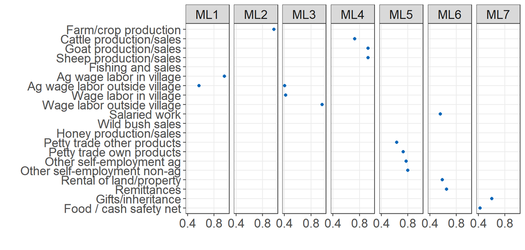

```r
ggplot(fa_inc_7_ldngsL, aes(x=loading, y=reorder(inc_code, desc(inc_code)), color=significance)) +
  #geom_bar() +
  geom_point() +
  scale_color_manual(values=c("grey60", medium_blue)) +
  scale_x_continuous(limits=c(.4,1),
                     breaks=c(.4,.8)) +
  scale_y_discrete(breaks=1:20,
                     labels=inc_labs) +
  facet_wrap(~factor, nrow=1) +
  faceted +
  theme(legend.position="none") +
  labs(x="",
       y="")
```

```r
ggsave(here("output/viz/fa inc 7 loadings.png"),
       device="png",
       type="cairo",
       height=5,
       width=10)
```

```r
g3 <- svyglm(fies_raw ~ grp_facs_comp + bonding_capital_comp + q_401_q_bin + q_401_r_bin +
               shock_exposure_index +
               as.factor(county),
             design=svydat)
```

[output not shown]

```r
summary(g3)
```

[output not shown]

#### 2.1.4.2 5 factors

```r
fa_inc_5 <- fa(inc,
               nfactors=5,
               scores="tenBerge",
               fm="ml",
               cor="tet")
```

```r
fa_inc_5
```

```
## Factor Analysis using method =  ml
## Call: fa(r = inc, nfactors = 5, scores = "tenBerge", fm = "ml", cor = "tet")
## Standardized loadings (pattern matrix) based upon correlation matrix
##               ML3   ML4   ML1   ML5   ML2    h2    u2 com
## q_401_a_bin  0.42  0.20  0.05  0.13 -0.22 0.327 0.673 2.3
## q_401_b_bin  0.79 -0.04 -0.12  0.04  0.03 0.604 0.396 1.1
## q_401_c_bin  0.92 -0.02  0.02 -0.05 -0.01 0.833 0.167 1.0
## q_401_d_bin  0.91  0.04  0.06  0.01 -0.01 0.885 0.115 1.0
## q_401_e_bin  0.14 -0.11  0.09  0.04  0.11 0.048 0.952 3.8
## q_401_f_bin  0.18  0.04  0.69 -0.01  0.14 0.666 0.334 1.2
## q_401_g_bin -0.03  0.01  0.99  0.04 -0.01 0.995 0.005 1.0
## q_401_h_bin -0.01  0.04  0.05 -0.02  0.97 0.995 0.005 1.0
## q_401_i_bin -0.02  0.08  0.51  0.15  0.34 0.667 0.333 2.0
## q_401_j_bin -0.14 -0.10  0.07  0.63 -0.03 0.381 0.619 1.2
## q_401_k_bin  0.26  0.13 -0.05  0.16  0.21 0.227 0.773 3.3
## q_401_l_bin  0.41  0.00  0.16  0.20  0.09 0.347 0.653 1.9
## q_401_m_bin  0.07  0.69  0.20 -0.03 -0.16 0.559 0.441 1.3
## q_401_n_bin -0.12  0.72  0.03 -0.03  0.02 0.494 0.506 1.1
## q_401_o_bin  0.08  0.80  0.03  0.00  0.05 0.739 0.261 1.0
## q_401_p_bin -0.03  0.74 -0.16  0.14  0.14 0.647 0.353 1.2
## q_401_q_bin  0.10  0.08 -0.01  0.81  0.02 0.762 0.238 1.1
## q_401_r_bin -0.15  0.05  0.17  0.54 -0.14 0.382 0.618 1.5
## q_401_s_bin  0.17 -0.03  0.02  0.31  0.23 0.221 0.779 2.5
## q_401_t_bin  0.12  0.03 -0.04  0.27  0.19 0.153 0.847 2.3
##
##                        ML3  ML4  ML1  ML5  ML2
## SS loadings           3.00 2.47 2.13 1.85 1.48
## Proportion Var        0.15 0.12 0.11 0.09 0.07
## Cumulative Var        0.15 0.27 0.38 0.47 0.55
## Proportion Explained  0.27 0.23 0.19 0.17 0.14
## Cumulative Proportion 0.27 0.50 0.69 0.86 1.00
##
##  With factor correlations of
##      ML3  ML4  ML1  ML5  ML2
## ML3 1.00 0.29 0.19 0.16 0.10
## ML4 0.29 1.00 0.36 0.43 0.34
## ML1 0.19 0.36 1.00 0.41 0.35
## ML5 0.16 0.43 0.41 1.00 0.18
## ML2 0.10 0.34 0.35 0.18 1.00
##
## Mean item complexity =  1.6
## Test of the hypothesis that 5 factors are sufficient.
##
## The degrees of freedom for the null model are  190  and the objective function was  11 with Chi Square of  86154
## The degrees of freedom for the model are 100  and the objective function was  1.84
##
## The root mean square of the residuals (RMSR) is  0.05
## The df corrected root mean square of the residuals is  0.07
##
## The harmonic number of observations is  7872 with the empirical chi square  8542  with prob <  0
## The total number of observations was  7872  with Likelihood Chi Square =  14466  with prob <  0
##
## Tucker Lewis Index of factoring reliability =  0.682
## RMSEA index =  0.135  and the 90 % confidence intervals are  0.133 0.137
## BIC =  13569
## Fit based upon off diagonal values = 0.97
## Measures of factor score adequacy
##                                                    ML3  ML4  ML1  ML5  ML2
## Correlation of (regression) scores with factors   0.97 0.93 1.00 0.91 1.00
## Multiple R square of scores with factors          0.94 0.87 0.99 0.83 0.99
## Minimum correlation of possible factor scores     0.88 0.74 0.99 0.65 0.99
```

```r
fa_inc_5_ldngs <- as.matrix(fa_inc_5$loadings) %>%
  unclass() %>%
  as.data.frame() %>%
  rownames_to_column("varname") %>%
  select(1:6) %>%
  left_join(inc_key) %>%
  select(1,7:9, everything()) %>%
  pivot_longer(cols=5:9,
               names_to="factor",
               values_to="loading") %>%
  #arrange(factor) %>%
  mutate(significance=ifelse(loading>.3999, "Significant loading", ""))

fa_inc_5_ldngs
```

Table 2.12:

| varname | inc_code | inc_lab | inc_lab2 | factor | loading | significance |
| --- | --- | --- | --- | --- | --- | --- |
| q_401_a_bin | 1 | Farm/crop production | a. Farm/crop production | ML3 | 0.42 | Significant loading |
| q_401_a_bin | 1 | Farm/crop production | a. Farm/crop production | ML4 | 0.2 |  |
| q_401_a_bin | 1 | Farm/crop production | a. Farm/crop production | ML1 | 0.0532 |  |
| q_401_a_bin | 1 | Farm/crop production | a. Farm/crop production | ML5 | 0.13 |  |
| q_401_a_bin | 1 | Farm/crop production | a. Farm/crop production | ML2 | -0.219 |  |
| q_401_b_bin | 2 | Cattle production/sales | b. Cattle production/sales | ML3 | 0.794 | Significant loading |
| q_401_b_bin | 2 | Cattle production/sales | b. Cattle production/sales | ML4 | -0.0387 |  |
| q_401_b_bin | 2 | Cattle production/sales | b. Cattle production/sales | ML1 | -0.118 |  |
| q_401_b_bin | 2 | Cattle production/sales | b. Cattle production/sales | ML5 | 0.0365 |  |
| q_401_b_bin | 2 | Cattle production/sales | b. Cattle production/sales | ML2 | 0.0259 |  |
| q_401_c_bin | 3 | Goat production/sales | c. Goat production/sales | ML3 | 0.921 | Significant loading |
| q_401_c_bin | 3 | Goat production/sales | c. Goat production/sales | ML4 | -0.0218 |  |
| q_401_c_bin | 3 | Goat production/sales | c. Goat production/sales | ML1 | 0.024 |  |
| q_401_c_bin | 3 | Goat production/sales | c. Goat production/sales | ML5 | -0.048 |  |
| q_401_c_bin | 3 | Goat production/sales | c. Goat production/sales | ML2 | -0.00972 |  |
| q_401_d_bin | 4 | Sheep production/sales | d. Sheep production/sales | ML3 | 0.913 | Significant loading |
| q_401_d_bin | 4 | Sheep production/sales | d. Sheep production/sales | ML4 | 0.0447 |  |
| q_401_d_bin | 4 | Sheep production/sales | d. Sheep production/sales | ML1 | 0.0577 |  |
| q_401_d_bin | 4 | Sheep production/sales | d. Sheep production/sales | ML5 | 0.00884 |  |
| q_401_d_bin | 4 | Sheep production/sales | d. Sheep production/sales | ML2 | -0.0118 |  |
| q_401_e_bin | 5 | Fishing and sales | e. Fishing and sales | ML3 | 0.143 |  |
| q_401_e_bin | 5 | Fishing and sales | e. Fishing and sales | ML4 | -0.109 |  |
| q_401_e_bin | 5 | Fishing and sales | e. Fishing and sales | ML1 | 0.0914 |  |
| q_401_e_bin | 5 | Fishing and sales | e. Fishing and sales | ML5 | 0.0432 |  |
| q_401_e_bin | 5 | Fishing and sales | e. Fishing and sales | ML2 | 0.106 |  |
| q_401_f_bin | 6 | Ag wage labor in village | f. Ag wage labor in village | ML3 | 0.175 |  |
| q_401_f_bin | 6 | Ag wage labor in village | f. Ag wage labor in village | ML4 | 0.0403 |  |
| q_401_f_bin | 6 | Ag wage labor in village | f. Ag wage labor in village | ML1 | 0.689 | Significant loading |
| q_401_f_bin | 6 | Ag wage labor in village | f. Ag wage labor in village | ML5 | -0.0128 |  |
| q_401_f_bin | 6 | Ag wage labor in village | f. Ag wage labor in village | ML2 | 0.141 |  |

[output cut: 70 more lines]

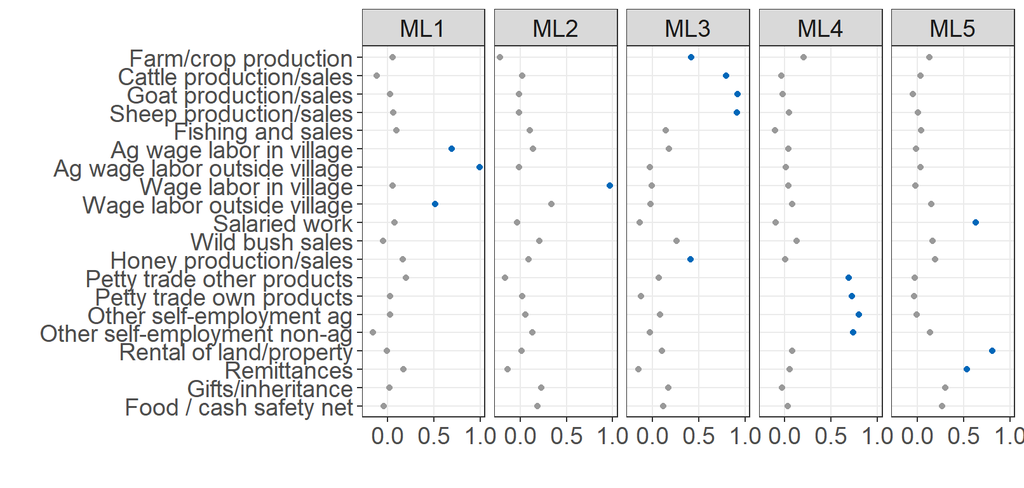

```r
ggplot(fa_inc_5_ldngs, aes(x=loading, y=reorder(inc_code, desc(inc_code)), color=significance)) +
  #geom_bar() +
  geom_point() +
  scale_color_manual(values=c("grey60", medium_blue)) +
  scale_x_continuous(breaks=seq(0,1,.5)) +
  scale_y_discrete(breaks=1:20,
                     labels=inc_labs) +
  facet_wrap(~factor, nrow=1) +
  faceted +
  theme(legend.position="none") +
  labs(x="",
       y="")
```

### 2.1.5 Inc factors, by ranking

```r
library(sjPlot)

frq(dat$q_402_a)
```

```
## Q 402_a: Rank sources - Own farming/crop production and sales (x) <numeric>
## # total N=7872 valid N=3922 mean=1.29 sd=0.64
##
## Value |    N | Raw % | Valid % | Cum. %
## ---------------------------------------
##     0 |   95 |  1.21 |    2.42 |   2.42
##     1 | 2895 | 36.78 |   73.81 |  76.24
##     2 |  622 |  7.90 |   15.86 |  92.10
##     3 |  310 |  3.94 |    7.90 | 100.00
##  <NA> | 3950 | 50.18 |    <NA> |   <NA>
```

```r
frq(dat$q_402_a_bin)
```

```r
inc_rank <- dat %>%
  select(q_402_a,
         q_402_b,
         q_402_c,
         q_402_d,
         q_402_e,
         q_402_f,
         q_402_g,
         q_402_h,
         q_402_i,
         q_402_j,
         q_402_k,
         q_402_l,
         q_402_m,
         q_402_n,
         q_402_o,
         q_402_p,
         q_402_q,
         q_402_r,
         q_402_s,
         q_402_t)

map(inc_rank, frq)
```

```
## $q_402_a
## Q 402_a: Rank sources - Own farming/crop production and sales (x) <numeric>
## # total N=7872 valid N=3922 mean=1.29 sd=0.64
##
## Value |    N | Raw % | Valid % | Cum. %
## ---------------------------------------
##     0 |   95 |  1.21 |    2.42 |   2.42
##     1 | 2895 | 36.78 |   73.81 |  76.24
##     2 |  622 |  7.90 |   15.86 |  92.10
##     3 |  310 |  3.94 |    7.90 | 100.00
##  <NA> | 3950 | 50.18 |    <NA> |   <NA>
##
## $q_402_b
## Q 402_b: Rank sources - Own cattle production/fattening and sales (x) <numeric>
## # total N=7872 valid N=3203 mean=1.57 sd=0.72
##
## Value |    N | Raw % | Valid % | Cum. %
## ---------------------------------------
##     0 |   86 |  1.09 |    2.68 |   2.68
##     1 | 1548 | 19.66 |   48.33 |  51.01
##     2 | 1222 | 15.52 |   38.15 |  89.17
##     3 |  347 |  4.41 |   10.83 | 100.00
##  <NA> | 4669 | 59.31 |    <NA> |   <NA>
##
## $q_402_c
## Q 402_c: Rank sources - Own goats production/fattening and sales (x) <numeric>
## # total N=7872 valid N=2967 mean=1.86 sd=0.87
##
## Value |    N | Raw % | Valid % | Cum. %
## ---------------------------------------
##     0 |  165 |  2.10 |    5.56 |   5.56
##     1 |  862 | 10.95 |   29.05 |  34.61
##     2 | 1149 | 14.60 |   38.73 |  73.34
##     3 |  791 | 10.05 |   26.66 | 100.00
##  <NA> | 4905 | 62.31 |    <NA> |   <NA>
##
## $q_402_d
## Q 402_d: Rank sources - Own sheep production/fattening and sales (x) <numeric>
## # total N=7872 valid N=1922 mean=1.62 sd=1.04
##
```

[output cut: 186 more lines]

```
##     2 |  355 |  4.51 |   26.51 |  57.36
##     3 |  571 |  7.25 |   42.64 | 100.00
##  <NA> | 6533 | 82.99 |    <NA> |   <NA>
##
## $q_402_t
## Q 402_t: Rank sources - Safety net food / cash assistance (x) <numeric>
## # total N=7872 valid N=1965 mean=1.67 sd=1.12
##
## Value |    N | Raw % | Valid % | Cum. %
## ---------------------------------------
##     0 |  420 |  5.34 |   21.37 |  21.37
##     1 |  415 |  5.27 |   21.12 |  42.49
##     2 |  531 |  6.75 |   27.02 |  69.52
##     3 |  599 |  7.61 |   30.48 | 100.00
##  <NA> | 5907 | 75.04 |    <NA> |   <NA>
```

```r
#sjt.stackfrq(inc)
```

```r
inc_rank[is.na(inc_rank)] <- 0

# inc_rank[inc_rank==3] <- 6
#
# inc_rank[inc_rank==2] <- 4
#
# inc_rank[is.na(inc_rank)] <- 0
```

```r
inc_labs
```

```
##  [1] "Farm/crop production"          "Cattle production/sales"
##  [3] "Goat production/sales"         "Sheep production/sales"
##  [5] "Fishing and sales"             "Ag wage labor in village"
##  [7] "Ag wage labor outside village" "Wage labor in village"
##  [9] "Wage labor outside village"    "Salaried work"
## [11] "Wild bush sales"               "Honey production/sales"
## [13] "Petty trade other products"    "Petty trade own products"
## [15] "Other self-employment ag"      "Other self-employment non-ag"
## [17] "Rental of land/property"       "Remittances"
## [19] "Gifts/inheritance"             "Food / cash safety net"
```

```r
inc_rank2 <- dat %>%
  mutate(farm_rank = ifelse(is.na(q_402_a), 0,
                            ifelse(q_402_a!=0, 4-q_402_a, 0)),
         cattle_rank = ifelse(is.na(q_402_b), 0,
                            ifelse(q_402_b!=0, 4-q_402_b, 0)),
         goat_rank = ifelse(is.na(q_402_c), 0,
                            ifelse(q_402_c!=0, 4-q_402_c, 0)),
         sheep_rank = ifelse(is.na(q_402_d), 0,
                            ifelse(q_402_d!=0, 4-q_402_d, 0)),
         fish_rank = ifelse(is.na(q_402_e), 0,
                            ifelse(q_402_e!=0, 4-q_402_e, 0)),
         agwage_in_rank = ifelse(is.na(q_402_f), 0,
                             ifelse(q_402_f!=0, 4-q_402_f, 0)),
         agwage_out_rank = ifelse(is.na(q_402_g), 0,
                            ifelse(q_402_g!=0, 4-q_402_g, 0)),
         wage_in_rank = ifelse(is.na(q_402_h), 0,
                            ifelse(q_402_h!=0, 4-q_402_h, 0)),
         wage_out_rank = ifelse(is.na(q_402_i), 0,
                            ifelse(q_402_i!=0, 4-q_402_i, 0)),
         salary_rank = ifelse(is.na(q_402_j), 0,
                            ifelse(q_402_j!=0, 4-q_402_j, 0)),
         bush_rank = ifelse(is.na(q_402_k), 0,
                            ifelse(q_402_k!=0, 4-q_402_k, 0)),
         honey_rank = ifelse(is.na(q_402_l), 0,
                            ifelse(q_402_l!=0, 4-q_402_l, 0)),
         petty_other_rank = ifelse(is.na(q_402_m), 0,
                            ifelse(q_402_m!=0, 4-q_402_m, 0)),
         petty_own_rank = ifelse(is.na(q_402_n), 0,
                            ifelse(q_402_n!=0, 4-q_402_n, 0)),
         other_ag_rank = ifelse(is.na(q_402_o), 0,
                            ifelse(q_402_o!=0, 4-q_402_o, 0)),
         other_nonag_rank = ifelse(is.na(q_402_p), 0,
                            ifelse(q_402_p!=0, 4-q_402_p, 0)),
         rent_rank = ifelse(is.na(q_402_q), 0,
                            ifelse(q_402_q!=0, 4-q_402_q, 0)),
         remit_rank = ifelse(is.na(q_402_r), 0,
                            ifelse(q_402_r!=0, 4-q_402_r, 0)),
         gift_rank = ifelse(is.na(q_402_s), 0,
                            ifelse(q_402_s!=0, 4-q_402_s, 0)),
         safety_rank = ifelse(is.na(q_402_t), 0,
                            ifelse(q_402_t!=0, 4-q_402_t, 0)),
         ) %>%
  select(farm_rank:safety_rank)

lapply(inc_rank2, mean)
```

```
## $farm_rank
## [1] 1.3
##
## $cattle_rank
## [1] 0.944
##
## $goat_rank
## [1] 0.721
##
## $sheep_rank
## [1] 0.404
##
## $fish_rank
## [1] 0.699
##
## $agwage_in_rank
## [1] 0.358
##
## $agwage_out_rank
## [1] 0.132
##
## $wage_in_rank
## [1] 0.443
##
## $wage_out_rank
## [1] 0.104
##
## $salary_rank
## [1] 0.199
##
## $bush_rank
## [1] 0.481
##
## $honey_rank
## [1] 0.184
##
## $petty_other_rank
## [1] 0.181
##
## $petty_own_rank
## [1] 0.187
##
## $other_ag_rank
## [1] 0.142
##
## $other_nonag_rank
## [1] 0.159
##
## $rent_rank
## [1] 0.0675
##
## $remit_rank
## [1] 0.0935
##
## $gift_rank
## [1] 0.239
##
## $safety_rank
## [1] 0.369
```

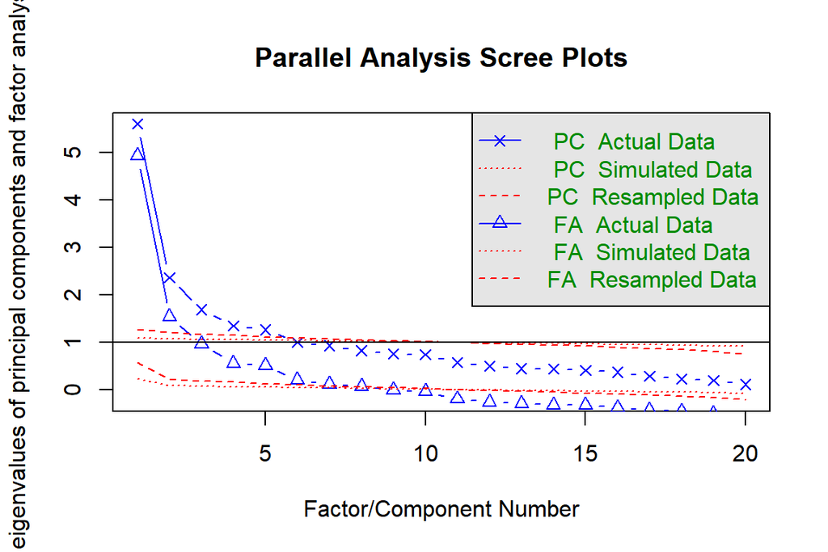

```
## Parallel analysis suggests that the number of factors =  8  and the number of components =  5
```

```r
fa.parallel(inc_rank2,
            cor="poly")
```

8 factors, 5 components

```r
fa_incrank2_8 <- fa(inc_rank2,
                    cor="poly",
                    nfactors=8,
                    scores="tenBerge",
                    fm="ml")

fa_incrank2_8
```

```
## Factor Analysis using method =  ml
## Call: fa(r = inc_rank2, nfactors = 8, scores = "tenBerge", fm = "ml",
##     cor = "poly")
## Standardized loadings (pattern matrix) based upon correlation matrix
##                    ML6   ML7   ML5   ML4   ML1   ML3   ML8   ML2   h2    u2 com
## farm_rank        -0.02  0.04  0.04  0.02 -0.01  0.98  0.02 -0.03 1.00 0.005 1.0
## cattle_rank       0.64 -0.03  0.02 -0.09 -0.02  0.02  0.10 -0.10 0.44 0.562 1.1
## goat_rank         0.88 -0.03  0.01  0.00  0.02 -0.02 -0.05 -0.02 0.73 0.265 1.0
## sheep_rank        0.80  0.13  0.05  0.08  0.00 -0.01  0.07 -0.01 0.84 0.160 1.1
## fish_rank        -0.11  0.00  0.05 -0.14  0.01 -0.19  0.42 -0.18 0.22 0.782 2.3
## agwage_in_rank    0.02  0.01 -0.01  1.00 -0.02  0.01  0.01 -0.02 1.00 0.005 1.0
## agwage_out_rank  -0.06 -0.07  0.13  0.48  0.37  0.01  0.02  0.08 0.59 0.410 2.2
## wage_in_rank     -0.05  0.13 -0.01  0.21  0.34 -0.25  0.09  0.01 0.34 0.660 3.2
## wage_out_rank     0.01  0.04  0.02 -0.01  0.97  0.00  0.02 -0.02 1.00 0.005 1.0
## salary_rank      -0.18 -0.01  0.57 -0.02  0.12 -0.06 -0.04  0.00 0.36 0.640 1.3
## bush_rank         0.07  0.36  0.10  0.11 -0.09 -0.12  0.30 -0.12 0.34 0.661 3.2
## honey_rank        0.12 -0.05 -0.02  0.06  0.10  0.14  0.68  0.14 0.64 0.358 1.3
## petty_other_rank  0.17  0.44  0.03  0.11  0.00  0.03 -0.10  0.26 0.48 0.524 2.3
## petty_own_rank   -0.04  0.04  0.02 -0.02 -0.02 -0.03  0.04  0.97 1.00 0.005 1.0
## other_ag_rank     0.04  0.82 -0.04  0.03  0.08  0.15  0.03  0.04 0.85 0.150 1.1
## other_nonag_rank  0.04  0.71  0.10 -0.02  0.06 -0.09 -0.06  0.10 0.64 0.361 1.2
## rent_rank         0.11 -0.02  0.93  0.00  0.03  0.09  0.01  0.05 1.00 0.005 1.1
## remit_rank       -0.21  0.22  0.50  0.08 -0.11 -0.14  0.09 -0.08 0.35 0.649 2.3
## gift_rank         0.03 -0.01  0.10  0.08  0.01 -0.11  0.54  0.08 0.40 0.595 1.3
## safety_rank      -0.01  0.32  0.07  0.04  0.01  0.10  0.34 -0.12 0.33 0.671 2.6
##
##                        ML6  ML7  ML5  ML4  ML1  ML3  ML8  ML2
## SS loadings           2.08 1.99 1.69 1.56 1.45 1.20 1.35 1.22
## Proportion Var        0.10 0.10 0.08 0.08 0.07 0.06 0.07 0.06
## Cumulative Var        0.10 0.20 0.29 0.37 0.44 0.50 0.57 0.63
## Proportion Explained  0.17 0.16 0.13 0.12 0.12 0.10 0.11 0.10
## Cumulative Proportion 0.17 0.32 0.46 0.58 0.70 0.80 0.90 1.00
##
##  With factor correlations of
##       ML6  ML7  ML5  ML4  ML1   ML3  ML8   ML2
## ML6  1.00 0.32 0.17 0.26 0.13  0.27 0.27 -0.08
## ML7  0.32 1.00 0.38 0.33 0.32  0.19 0.23  0.39
## ML5  0.17 0.38 1.00 0.28 0.40  0.15 0.31  0.24
## ML4  0.26 0.33 0.28 1.00 0.42  0.15 0.34  0.12
## ML1  0.13 0.32 0.40 0.42 1.00  0.06 0.26  0.16
```

[output cut: 14 more lines]

```
## The total number of observations was  7872  with Likelihood Chi Square =  5187  with prob <  0
##
## Tucker Lewis Index of factoring reliability =  0.754
## RMSEA index =  0.106  and the 90 % confidence intervals are  0.104 0.108
## BIC =  4667
## Fit based upon off diagonal values = 0.99
## Measures of factor score adequacy
##                                                    ML6  ML7  ML5  ML4  ML1  ML3
## Correlation of (regression) scores with factors   0.94 0.94 1.00 1.00 1.00 1.00
## Multiple R square of scores with factors          0.89 0.88 0.99 0.99 0.99 0.99
## Minimum correlation of possible factor scores     0.78 0.76 0.98 0.99 0.99 0.99
##                                                    ML8  ML2
## Correlation of (regression) scores with factors   0.85 1.00
## Multiple R square of scores with factors          0.73 0.99
## Minimum correlation of possible factor scores     0.45 0.99
```

ML6: goats, sheep, cattle

ML7: other ag, other non ag, petty trade other

ML5: rent, remittances, salary

ML4: ag wage in village, ag wage out of village

ML1: wage out of village

ML3: farmer

ML8: honey, gift, fish

ML2: petty trade own goods

```r
fa_incrank2_8_scrs <- fa_incrank2_8$scores %>%
  unlist() %>%
  as.data.frame()


dat <- dat %>%
  mutate(incrank_fac_livestock = fa_incrank2_8_scrs$ML6,
         incrank_fac_selfemployed = fa_incrank2_8_scrs$ML7,
         incrank_fac_rentremitsal = fa_incrank2_8_scrs$ML5,
         incrank_fac_agwage = fa_incrank2_8_scrs$ML4,
         incrank_fac_wageout = fa_incrank2_8_scrs$ML1,
         incrank_fac_farm = fa_incrank2_8_scrs$ML3,
         incrank_fac_honeygiftfish = fa_incrank2_8_scrs$ML8,
         incrank_fac_pettytradeown = fa_incrank2_8_scrs$ML2)
```

```r
l1 <- svyglm(fies_raw ~
               incrank_fac_livestock +
               incrank_fac_selfemployed +
               incrank_fac_rentremitsal +
               incrank_fac_agwage +
               incrank_fac_wageout +
               incrank_fac_farm +
               incrank_fac_honeygiftfish +
               incrank_fac_pettytradeown +
               household_members + as.factor(hh_head_sex) + urban + as.factor(county),
             design=svydat)

summary(l1)
```

```
##
## Call:
## svyglm(formula = fies_raw ~ incrank_fac_livestock + incrank_fac_selfemployed +
##     incrank_fac_rentremitsal + incrank_fac_agwage + incrank_fac_wageout +
##     incrank_fac_farm + incrank_fac_honeygiftfish + incrank_fac_pettytradeown +
##     household_members + as.factor(hh_head_sex) + urban + as.factor(county),
##     design = svydat)
##
## Survey design:
## svydesign(data = dat, ids = ~ea, weights = ~final_wt1, strata = ~county)
##
## Coefficients:
##                                Estimate Std. Error t value Pr(>|t|)
## (Intercept)                      7.4244     0.1856   39.99  < 2e-16 ***
## incrank_fac_livestock            0.0669     0.0456    1.47   0.1427
## incrank_fac_selfemployed        -0.0264     0.0590   -0.45   0.6554
## incrank_fac_rentremitsal        -0.1457     0.0507   -2.88   0.0043 **
## incrank_fac_agwage               0.1070     0.0607    1.76   0.0786 .
## incrank_fac_wageout             -0.0359     0.0611   -0.59   0.5576
## incrank_fac_farm                 0.0206     0.0480    0.43   0.6688
## incrank_fac_honeygiftfish        0.0252     0.0456    0.55   0.5810
## incrank_fac_pettytradeown       -0.1285     0.1057   -1.22   0.2251
## household_members                0.0229     0.0191    1.20   0.2312
## as.factor(hh_head_sex)2          0.0843     0.0603    1.40   0.1631
## urban                            0.2149     0.1237    1.74   0.0833 .
## as.factor(county)Baliet         -0.1703     0.2211   -0.77   0.4419
## as.factor(county)Budi           -0.7130     0.2968   -2.40   0.0168 *
## as.factor(county)Duk            -0.0407     0.2333   -0.17   0.8615
## as.factor(county)Jur River      -0.5021     0.1689   -2.97   0.0032 **
## as.factor(county)Kapoeta North   0.4048     0.2418    1.67   0.0950 .
## as.factor(county)Leer            0.3220     0.1235    2.61   0.0095 **
## as.factor(county)Mayendit        0.1453     0.1661    0.87   0.3823
## as.factor(county)Paynijar        0.3956     0.1208    3.27   0.0012 **
## as.factor(county)Pibor           0.1646     0.1911    0.86   0.3898
## as.factor(county)Ulang           0.1627     0.1435    1.13   0.2578
## as.factor(county)Uror            0.1870     0.1576    1.19   0.2363
## as.factor(county)Wau            -1.2096     0.2865   -4.22 0.000031 ***
## ---
## Signif. codes:  0 '***' 0.001 '**' 0.01 '*' 0.05 '.' 0.1 ' ' 1
##
## (Dispersion parameter for gaussian family taken to be 1.67)
##
## Number of Fisher Scoring iterations: 2
```

### 2.1.6 Shock preparedness and mitigation

Nothing from the TANGO manual, but from our instrument we have early warning systems and emergency action plans

#### 2.1.6.1 Early warning system

```r
ews <- dat %>%
  select(warn_hazards:warn_foodprices)

map(ews, frq)
```

```
## $warn_hazards
## x <numeric>
## # total N=7872 valid N=7806 mean=0.33 sd=0.47
##
## Value |    N | Raw % | Valid % | Cum. %
## ---------------------------------------
##     0 | 5249 | 66.68 |   67.24 |  67.24
##     1 | 2557 | 32.48 |   32.76 | 100.00
##  <NA> |   66 |  0.84 |    <NA> |   <NA>
##
## $warn_weather
## x <numeric>
## # total N=7872 valid N=7811 mean=0.27 sd=0.45
##
## Value |    N | Raw % | Valid % | Cum. %
## ---------------------------------------
##     0 | 5680 | 72.15 |   72.72 |  72.72
##     1 | 2131 | 27.07 |   27.28 | 100.00
##  <NA> |   61 |  0.77 |    <NA> |   <NA>
##
## $warn_rainfall
## x <numeric>
## # total N=7872 valid N=7815 mean=0.35 sd=0.48
##
## Value |    N | Raw % | Valid % | Cum. %
## ---------------------------------------
##     0 | 5110 | 64.91 |   65.39 |  65.39
##     1 | 2705 | 34.36 |   34.61 | 100.00
##  <NA> |   57 |  0.72 |    <NA> |   <NA>
##
## $warn_water
## x <numeric>
## # total N=7872 valid N=7812 mean=0.22 sd=0.42
##
## Value |    N | Raw % | Valid % | Cum. %
## ---------------------------------------
##     0 | 6056 | 76.93 |   77.52 |  77.52
##     1 | 1756 | 22.31 |   22.48 | 100.00
##  <NA> |   60 |  0.76 |    <NA> |   <NA>
##
```

[output cut: 54 more lines]

```
## Value |    N | Raw % | Valid % | Cum. %
## ---------------------------------------
##     0 | 4906 | 62.32 |   62.83 |  62.83
##     1 | 2902 | 36.86 |   37.17 | 100.00
##  <NA> |   64 |  0.81 |    <NA> |   <NA>
##
## $warn_foodprices
## x <numeric>
## # total N=7872 valid N=7779 mean=0.46 sd=0.50
##
## Value |    N | Raw % | Valid % | Cum. %
## ---------------------------------------
##     0 | 4186 | 53.18 |   53.81 |  53.81
##     1 | 3593 | 45.64 |   46.19 | 100.00
##  <NA> |   93 |  1.18 |    <NA> |   <NA>
```

##### 2.1.6.1.1 rank frequencies

```r
names(ews)
```

```
##  [1] "warn_hazards"      "warn_weather"      "warn_rainfall"
##  [4] "warn_water"        "warn_livestock"    "warn_crops"
##  [7] "warn_animalprices" "warn_prices"       "warn_grazing"
## [10] "warn_conflict"     "warn_foodprices"
```

```r
ews_temp <- svyrdat %>%
  summarize(warn_hazards = survey_mean(warn_hazards, na.rm=T),
            warn_weather = survey_mean(warn_weather, na.rm=T),
            warn_rainfall = survey_mean(warn_rainfall, na.rm=T),
            warn_waterprices = survey_mean(warn_water, na.rm=T),
            warn_animalhealth = survey_mean(warn_livestock, na.rm=T),
            warn_crophealth = survey_mean(warn_crops, na.rm=T),
            warn_livestockprices = survey_mean(warn_animalprices, na.rm=T),
            warn_animalproductprices = survey_mean(warn_prices, na.rm=T),
            warn_grazing = survey_mean(warn_grazing, na.rm=T),
            warn_conflict = survey_mean(warn_conflict, na.rm=T),
            warn_foodprices = survey_mean(warn_foodprices, na.rm=T))

grps_temp
```

Table 2.13:

[output not shown]

```r
ews_mn <- ews_temp %>%
  select(!contains("se")) %>%
  melt() %>%
  mutate(ews = ews_labs) %>%
  select(1,3,2)


ews_se <- ews_temp %>%
  select(contains("se")) %>%
  melt() %>%
  rename(se=value)

ews_se
```

Table 2.14:

| variable | se |
| --- | --- |
| warn_hazards_se | 0.0174 |
| warn_weather_se | 0.0184 |
| warn_rainfall_se | 0.0191 |
| warn_waterprices_se | 0.0167 |
| warn_animalhealth_se | 0.0133 |
| warn_crophealth_se | 0.013 |
| warn_livestockprices_se | 0.0188 |
| warn_animalproductprices_se | 0.021 |
| warn_grazing_se | 0.0203 |
| warn_conflict_se | 0.0187 |
| warn_foodprices_se | 0.0195 |

```r
ews_sum <- ews_mn %>%
  cbind(ews_se[,2]) %>%
  rename(percent=value,
         se = 4) %>%
  mutate(lower=percent-1.96*se,
         upper=percent+1.96*se) %>%
  arrange(desc(percent))

ews_sum
```

Table 2.14:

| variable | ews | percent | se | lower | upper |
| --- | --- | --- | --- | --- | --- |
| warn_foodprices | Food prices | 0.454 | 0.0195 | 0.416 | 0.492 |
| warn_conflict | Conflict | 0.428 | 0.0187 | 0.392 | 0.465 |
| warn_rainfall | Upcoming rainfall | 0.398 | 0.0191 | 0.36 | 0.435 |
| warn_animalproductprices | Animal product prices | 0.383 | 0.021 | 0.341 | 0.424 |
| warn_livestockprices | Livestock prices | 0.341 | 0.0188 | 0.304 | 0.377 |
| warn_hazards | Natural hazards | 0.328 | 0.0174 | 0.294 | 0.362 |
| warn_grazing | Grazing conditions | 0.325 | 0.0203 | 0.285 | 0.365 |
| warn_weather | Weather patterns | 0.301 | 0.0184 | 0.265 | 0.337 |
| warn_waterprices | Water prices/availability | 0.257 | 0.0167 | 0.225 | 0.29 |
| warn_crophealth | Crop health | 0.25 | 0.013 | 0.225 | 0.276 |
| warn_animalhealth | Animal health | 0.246 | 0.0133 | 0.22 | 0.272 |

```r
write_csv(ews_sum, here("output/tables/resilience/ews weighted.csv"))

ews_sum_gt <- ews_sum %>%
  gt() %>%
  fmt_percent(3:6, decimals=1)

ews_sum_gt
```

| variable | ews | percent | se | lower | upper |
| --- | --- | --- | --- | --- | --- |
| warn_foodprices | Food prices | 45.4% | 1.9% | 41.6% | 49.2% |
| warn_conflict | Conflict | 42.8% | 1.9% | 39.2% | 46.5% |
| warn_rainfall | Upcoming rainfall | 39.8% | 1.9% | 36.0% | 43.5% |
| warn_animalproductprices | Animal product prices | 38.3% | 2.1% | 34.1% | 42.4% |
| warn_livestockprices | Livestock prices | 34.1% | 1.9% | 30.4% | 37.7% |
| warn_hazards | Natural hazards | 32.8% | 1.7% | 29.4% | 36.2% |
| warn_grazing | Grazing conditions | 32.5% | 2.0% | 28.5% | 36.5% |
| warn_weather | Weather patterns | 30.1% | 1.8% | 26.5% | 33.7% |
| warn_waterprices | Water prices/availability | 25.7% | 1.7% | 22.5% | 29.0% |
| warn_crophealth | Crop health | 25.0% | 1.3% | 22.5% | 27.6% |
| warn_animalhealth | Animal health | 24.6% | 1.3% | 22.0% | 27.2% |

```r
gtsave(ews_sum_gt, here("output/tables/resilience/ews weighted.rtf"))
```

##### 2.1.6.1.2 IRT

```r
ltm_ews <- ltm(ews ~ z1)
ltm_ews
```

```
##
## Call:
## ltm(formula = ews ~ z1)
##
## Coefficients:
##                    Dffclt  Dscrmn
## warn_hazards        0.637    1.67
## warn_weather        0.799    1.96
## warn_rainfall       0.506    2.15
## warn_water          1.017    1.88
## warn_livestock      0.782    1.91
## warn_crops          0.784    1.97
## warn_animalprices   0.624    2.44
## warn_prices         0.479    2.40
## warn_grazing        0.776    2.61
## warn_conflict       0.451    1.80
## warn_foodprices     0.135    1.71
##
## Log.Lik: -42386
```

animal prices, general prices, and grazing highest discrimination

```r
ltm_ews_out <- coef(ltm_ews) %>%
  as.data.frame() %>%
  rownames_to_column("variable") %>%
  mutate(item=ews_labs) %>%
  select(1,4, difficulty=2,discrimination=3)

ltm_ews_out
```

Table 2.15:

| variable | item | difficulty | discrimination |
| --- | --- | --- | --- |
| warn_hazards | Natural hazards | 0.637 | 1.67 |
| warn_weather | Weather patterns | 0.799 | 1.96 |
| warn_rainfall | Upcoming rainfall | 0.506 | 2.16 |
| warn_water | Water prices/availability | 1.02 | 1.88 |
| warn_livestock | Animal health | 0.782 | 1.91 |
| warn_crops | Crop health | 0.784 | 1.97 |
| warn_animalprices | Livestock prices | 0.624 | 2.44 |
| warn_prices | Animal product prices | 0.479 | 2.4 |
| warn_grazing | Grazing conditions | 0.776 | 2.61 |
| warn_conflict | Conflict | 0.451 | 1.8 |
| warn_foodprices | Food prices | 0.135 | 1.71 |

```r
write_csv(ltm_ews_out, here("output/tables/resilience/ews irt.csv"))

ltm_ews_gt <- ltm_ews_out %>%
  gt() %>%
  fmt_number(3:4,
             decimals=2)

ltm_ews_gt
```

| variable | item | difficulty | discrimination |
| --- | --- | --- | --- |
| warn_hazards | Natural hazards | 0.64 | 1.67 |
| warn_weather | Weather patterns | 0.80 | 1.96 |
| warn_rainfall | Upcoming rainfall | 0.51 | 2.16 |
| warn_water | Water prices/availability | 1.02 | 1.88 |
| warn_livestock | Animal health | 0.78 | 1.91 |
| warn_crops | Crop health | 0.78 | 1.97 |
| warn_animalprices | Livestock prices | 0.62 | 2.44 |
| warn_prices | Animal product prices | 0.48 | 2.40 |
| warn_grazing | Grazing conditions | 0.78 | 2.61 |
| warn_conflict | Conflict | 0.45 | 1.80 |
| warn_foodprices | Food prices | 0.14 | 1.71 |

```r
gtsave(ltm_ews_gt, here("output/tables/resilience/ews irt.rtf"))
```

##### 2.1.6.1.3 Factor analysis

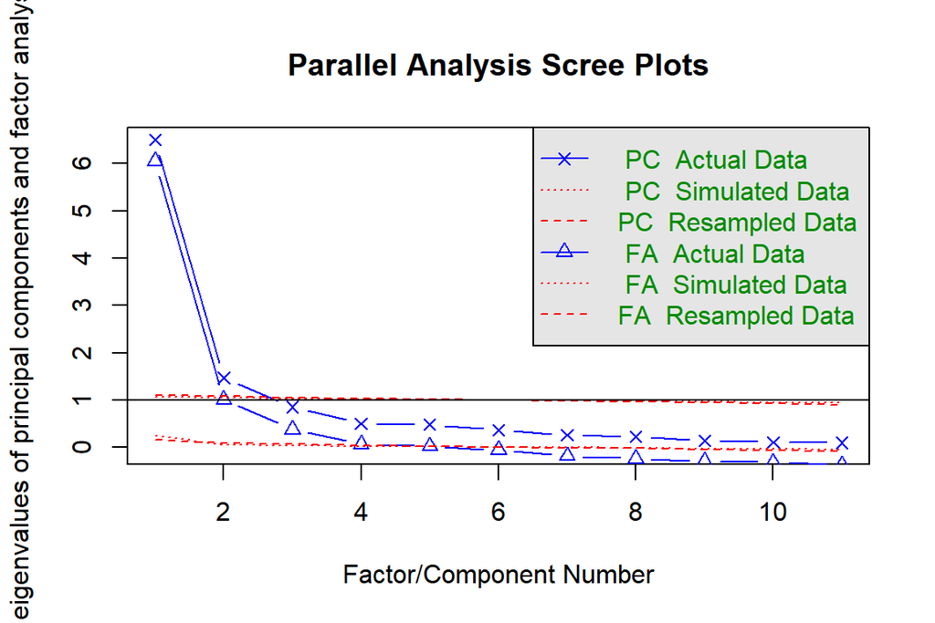

```
## Parallel analysis suggests that the number of factors =  4  and the number of components =  2
```

```r
fa.parallel(ews,
            cor="tet")
```

4 factors, 2 components

```r
fa_ews_4 <- fa(ews,
               nfactors=4,
               scores="tenBerge",
               fm="ml",
               cor="tet")
```

```r
fa_ews_4
```

```
## Factor Analysis using method =  ml
## Call: fa(r = ews, nfactors = 4, scores = "tenBerge", fm = "ml", cor = "tet")
## Standardized loadings (pattern matrix) based upon correlation matrix
##                     ML3   ML4   ML1   ML2   h2    u2 com
## warn_hazards      -0.02  0.82 -0.01  0.06 0.69 0.305 1.0
## warn_weather      -0.05  0.97  0.03 -0.05 0.90 0.100 1.0
## warn_rainfall      0.10  0.82 -0.02  0.04 0.78 0.222 1.0
## warn_water         0.41  0.27  0.11  0.05 0.50 0.505 1.9
## warn_livestock    -0.02 -0.03  1.03 -0.01 1.00 0.005 1.0
## warn_crops         0.04  0.05  0.83  0.04 0.81 0.185 1.0
## warn_animalprices  0.90  0.00  0.06 -0.02 0.84 0.160 1.0
## warn_prices        1.00 -0.01  0.00 -0.05 0.94 0.064 1.0
## warn_grazing       0.44  0.26  0.10  0.20 0.67 0.325 2.2
## warn_conflict      0.00  0.01  0.03  0.98 1.00 0.005 1.0
## warn_foodprices    0.69 -0.01 -0.06  0.22 0.66 0.344 1.2
##
##                        ML3  ML4  ML1  ML2
## SS loadings           2.96 2.65 1.90 1.26
## Proportion Var        0.27 0.24 0.17 0.11
## Cumulative Var        0.27 0.51 0.68 0.80
## Proportion Explained  0.34 0.30 0.22 0.14
## Cumulative Proportion 0.34 0.64 0.86 1.00
##
##  With factor correlations of
##      ML3  ML4  ML1  ML2
## ML3 1.00 0.50 0.48 0.61
## ML4 0.50 1.00 0.64 0.49
## ML1 0.48 0.64 1.00 0.52
## ML2 0.61 0.49 0.52 1.00
##
## Mean item complexity =  1.2
## Test of the hypothesis that 4 factors are sufficient.
##
## The degrees of freedom for the null model are  55  and the objective function was  9.67 with Chi Square of  76102
## The degrees of freedom for the model are 17  and the objective function was  0.16
##
## The root mean square of the residuals (RMSR) is  0.02
## The df corrected root mean square of the residuals is  0.03
##
## The harmonic number of observations is  7788 with the empirical chi square  251  with prob <  1.2e-43
## The total number of observations was  7872  with Likelihood Chi Square =  1221  with prob <  4e-249
##
## Tucker Lewis Index of factoring reliability =  0.949
## RMSEA index =  0.095  and the 90 % confidence intervals are  0.09 0.099
## BIC =  1069
## Fit based upon off diagonal values = 1
## Measures of factor score adequacy
##                                                    ML3  ML4  ML1  ML2
## Correlation of (regression) scores with factors   0.98 0.97 1.00 1.00
## Multiple R square of scores with factors          0.96 0.94 1.00 0.99
## Minimum correlation of possible factor scores     0.92 0.88 0.99 0.99
```

```r
fa_ews_4_ldngs <- as.matrix(fa_ews_4$loadings) %>%
  unclass() %>%
  as.data.frame() %>%
  mutate(description=ews_labs,
         difficulty=ltm_ews_out$difficulty,
         discrimination=ltm_ews_out$discrimination) %>%
  rownames_to_column("variable") %>%
  relocate(description,.after=variable)

fa_ews_4_ldngs
```

Table 2.16:

| variable | description | ML3 | ML4 | ML1 | ML2 | difficulty | discrimination |
| --- | --- | --- | --- | --- | --- | --- | --- |
| warn_hazards | Natural hazards | -0.0216 | 0.817 | -0.00732 | 0.0622 | 0.637 | 1.67 |
| warn_weather | Weather patterns | -0.0472 | 0.974 | 0.0337 | -0.0533 | 0.799 | 1.96 |
| warn_rainfall | Upcoming rainfall | 0.102 | 0.818 | -0.0203 | 0.0391 | 0.506 | 2.16 |
| warn_water | Water prices/availability | 0.412 | 0.271 | 0.109 | 0.0517 | 1.02 | 1.88 |
| warn_livestock | Animal health | -0.017 | -0.0268 | 1.03 | -0.0071 | 0.782 | 1.91 |
| warn_crops | Crop health | 0.0398 | 0.0483 | 0.831 | 0.0354 | 0.784 | 1.97 |
| warn_animalprices | Livestock prices | 0.896 | 0.00381 | 0.057 | -0.0171 | 0.624 | 2.44 |
| warn_prices | Animal product prices | 1 | -0.00909 | -0.000219 | -0.0487 | 0.479 | 2.4 |
| warn_grazing | Grazing conditions | 0.445 | 0.258 | 0.0956 | 0.197 | 0.776 | 2.61 |
| warn_conflict | Conflict | 0.00308 | 0.00765 | 0.03 | 0.976 | 0.451 | 1.8 |
| warn_foodprices | Food prices | 0.693 | -0.0127 | -0.0647 | 0.225 | 0.135 | 1.71 |

```r
write_csv(fa_ews_4_ldngs, here("output/tables/resilience/ews loadings.csv"))

fa_ews_gt <- fa_ews_4_ldngs %>%
  gt() %>%
  fmt_number(3:8, decimals=2)

fa_ews_gt
```

| variable | description | ML3 | ML4 | ML1 | ML2 | difficulty | discrimination |
| --- | --- | --- | --- | --- | --- | --- | --- |
| warn_hazards | Natural hazards | −0.02 | 0.82 | −0.01 | 0.06 | 0.64 | 1.67 |
| warn_weather | Weather patterns | −0.05 | 0.97 | 0.03 | −0.05 | 0.80 | 1.96 |
| warn_rainfall | Upcoming rainfall | 0.10 | 0.82 | −0.02 | 0.04 | 0.51 | 2.16 |
| warn_water | Water prices/availability | 0.41 | 0.27 | 0.11 | 0.05 | 1.02 | 1.88 |
| warn_livestock | Animal health | −0.02 | −0.03 | 1.03 | −0.01 | 0.78 | 1.91 |
| warn_crops | Crop health | 0.04 | 0.05 | 0.83 | 0.04 | 0.78 | 1.97 |
| warn_animalprices | Livestock prices | 0.90 | 0.00 | 0.06 | −0.02 | 0.62 | 2.44 |
| warn_prices | Animal product prices | 1.00 | −0.01 | 0.00 | −0.05 | 0.48 | 2.40 |
| warn_grazing | Grazing conditions | 0.44 | 0.26 | 0.10 | 0.20 | 0.78 | 2.61 |
| warn_conflict | Conflict | 0.00 | 0.01 | 0.03 | 0.98 | 0.45 | 1.80 |
| warn_foodprices | Food prices | 0.69 | −0.01 | −0.06 | 0.22 | 0.14 | 1.71 |

```r
gtsave(fa_ews_gt, here("output/tables/resilience/ews loadings.rtf"))
```

ML3: prices, animal prices, food prices

ML4: weather, hazards, rain

ML1: livestock, crops

ML2: conflict

```r
fa_ews_4_scores <- data.frame(fa_ews_4$scores)

dat <- dat %>%
  mutate(ews_fac_prices = fa_ews_4_scores$ML3,
         ews_fac_weather = fa_ews_4_scores$ML4,
         ews_fac_farming = fa_ews_4_scores$ML1,
         ews_fac_conflict = fa_ews_4_scores$ML2)
```

```r
fa_ews_4_ldngsL <- fa_ews_4_ldngs %>%
  pivot_longer(cols=2:5,
               names_to="factor",
               values_to="loading") %>%
  #arrange(factor) %>%
  mutate(significance=ifelse(loading>.3999, "Significant loading", ""))
```

[output not shown]

```r
fa_ews_4_ldngsL
```

[output not shown]

```r
ggplot(fa_ews_4_ldngsL, aes(x=loading, y=varname, color=significance)) +
  #geom_bar() +
  geom_point() +
  scale_color_manual(values=c("grey60", medium_blue)) +
  scale_x_continuous(limits=c(.4,1),
                     breaks=c(.4,.8)) +
  scale_y_discrete(breaks=1:20,
                     labels=inc_labs) +
  facet_wrap(~factor, nrow=1) +
  faceted +
  theme(legend.position="none") +
  labs(x="",
       y="")
```

[output not shown]

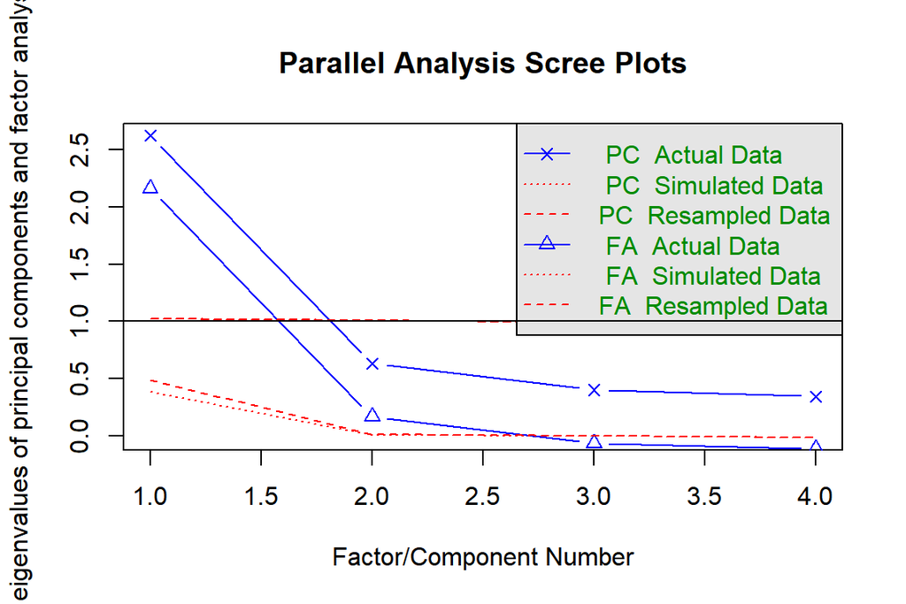

```
## Parallel analysis suggests that the number of factors =  2  and the number of components =  1
```

```r
ews_facs <- dat %>%
  select(ews_fac_prices:ews_fac_conflict)

fa.parallel(ews_facs)
```

2 factors, 1 component

```r
fa_ews_facs <- fa(ews_facs,
                  scores="tenBerge",
                  fm="ml")

fa_ews_facs
```

```
## Factor Analysis using method =  ml
## Call: fa(r = ews_facs, scores = "tenBerge", fm = "ml")
## Standardized loadings (pattern matrix) based upon correlation matrix
##                   ML1   h2   u2 com
## ews_fac_prices   0.71 0.50 0.50   1
## ews_fac_weather  0.75 0.57 0.43   1
## ews_fac_farming  0.76 0.57 0.43   1
## ews_fac_conflict 0.72 0.52 0.48   1
##
##                 ML1
## SS loadings    2.16
## Proportion Var 0.54
##
## Mean item complexity =  1
## Test of the hypothesis that 1 factor is sufficient.
##
## The degrees of freedom for the null model are  6  and the objective function was  1.47 with Chi Square of  11543
## The degrees of freedom for the model are 2  and the objective function was  0.1
##
## The root mean square of the residuals (RMSR) is  0.06
## The df corrected root mean square of the residuals is  0.11
##
## The harmonic number of observations is  7656 with the empirical chi square  350  with prob <  9.6e-77
## The total number of observations was  7872  with Likelihood Chi Square =  780  with prob <  3.7e-170
##
## Tucker Lewis Index of factoring reliability =  0.798
## RMSEA index =  0.222  and the 90 % confidence intervals are  0.209 0.236
## BIC =  762
## Fit based upon off diagonal values = 0.99
## Measures of factor score adequacy
##                                                    ML1
## Correlation of (regression) scores with factors   0.91
## Multiple R square of scores with factors          0.83
## Minimum correlation of possible factor scores     0.65
```

```r
fa_ews_facs_ldngs <- as.matrix(fa_ews_facs$loadings) %>%
  unclass() %>%
  as.data.frame() %>%
  mutate(description=c("Animal product/livestock/food prices",
                       "Natural hazards/weather",
                       "Animal/crop health",
                       "Conflict")) %>%
  rownames_to_column("factor") %>%
  relocate(description,.after=factor)

fa_ews_facs_ldngs
```

Table 2.17:

| factor | description | ML1 |
| --- | --- | --- |
| ews_fac_prices | Animal product/livestock/food prices | 0.707 |
| ews_fac_weather | Natural hazards/weather | 0.752 |
| ews_fac_farming | Animal/crop health | 0.758 |
| ews_fac_conflict | Conflict | 0.721 |

```r
write_csv(fa_ews_facs_ldngs, here("output/tables/resilience/ews facs loadings.csv"))

fa_ews_facs_gt <- fa_ews_facs_ldngs %>%
  gt() %>%
  fmt_number(3, decimals=2)

fa_ews_facs_gt
```

| factor | description | ML1 |
| --- | --- | --- |
| ews_fac_prices | Animal product/livestock/food prices | 0.71 |
| ews_fac_weather | Natural hazards/weather | 0.75 |
| ews_fac_farming | Animal/crop health | 0.76 |
| ews_fac_conflict | Conflict | 0.72 |

```r
gtsave(fa_ews_facs_gt, here("output/tables/resilience/ews facs loadings.rtf"))
```

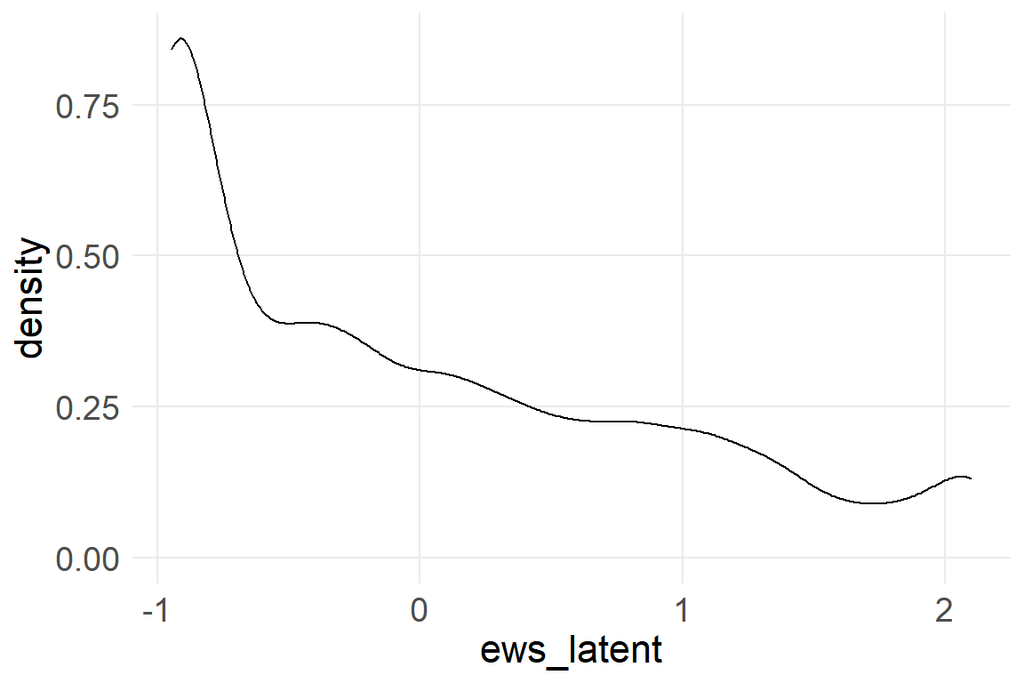

```r
fa_ews_facs_scrs <- fa_ews_facs$scores %>%
  unlist() %>%
  as.data.frame()

dat <- dat %>%
  mutate(ews_latent = fa_ews_facs_scrs$ML1,
         ews_latent_resc = scales::rescale(ews_latent, c(0,100)))

ggplot(dat, aes(ews_latent)) +
  geom_density()
```

```r
ews_latent_mn <- svyrdat %>%
  summarize(ews = survey_mean(grp_latent_resc, na.rm=T)) %>%
  mutate(lower=ews-1.96*ews_se,
         upper=ews+1.96*ews_se)

ews_latent_mn
```

Table 2.18:

[output not shown]

```r
ews_prin <- principal(ews,
                      cor="tet")
```

```r
ews_prin
```

```
## Principal Components Analysis
## Call: principal(r = ews, cor = "tet")
## Standardized loadings (pattern matrix) based upon correlation matrix
##                    PC1   h2   u2 com
## warn_hazards      0.73 0.53 0.47   1
## warn_weather      0.76 0.58 0.42   1
## warn_rainfall     0.80 0.64 0.36   1
## warn_water        0.75 0.57 0.43   1
## warn_livestock    0.75 0.56 0.44   1
## warn_crops        0.76 0.58 0.42   1
## warn_animalprices 0.80 0.63 0.37   1
## warn_prices       0.79 0.63 0.37   1
## warn_grazing      0.83 0.69 0.31   1
## warn_conflict     0.75 0.56 0.44   1
## warn_foodprices   0.72 0.52 0.48   1
##
##                 PC1
## SS loadings    6.50
## Proportion Var 0.59
##
## Mean item complexity =  1
## Test of the hypothesis that 1 component is sufficient.
##
## The root mean square of the residuals (RMSR) is  0.13
##  with the empirical chi square  14090  with prob <  0
##
## Fit based upon off diagonal values = 0.95
```

```r
ews_prin_scrs <- ews_prin$scores %>%
  as.data.frame()

dat <- dat %>%
  mutate(ews_comp=ews_prin_scrs$PC1)

describe(dat$ews_comp)
```

Table 2.19:

| vars | n | mean | sd | median | trimmed | mad | min | max | range | skew | kurtosis | se |
| --- | --- | --- | --- | --- | --- | --- | --- | --- | --- | --- | --- | --- |
| 1 | 7.66e+03 | 0.000822 | 0.84 | -0.143 | -0.101 | 1.1 | -0.883 | 1.95 | 2.83 | 0.743 | -0.52 | 0.0096 |

```r
ews_prin$weights
```

```
##                     PC1
## warn_hazards      0.112
## warn_weather      0.117
## warn_rainfall     0.123
## warn_water        0.116
## warn_livestock    0.116
## warn_crops        0.117
## warn_animalprices 0.122
## warn_prices       0.122
## warn_grazing      0.128
## warn_conflict     0.115
## warn_foodprices   0.111
```

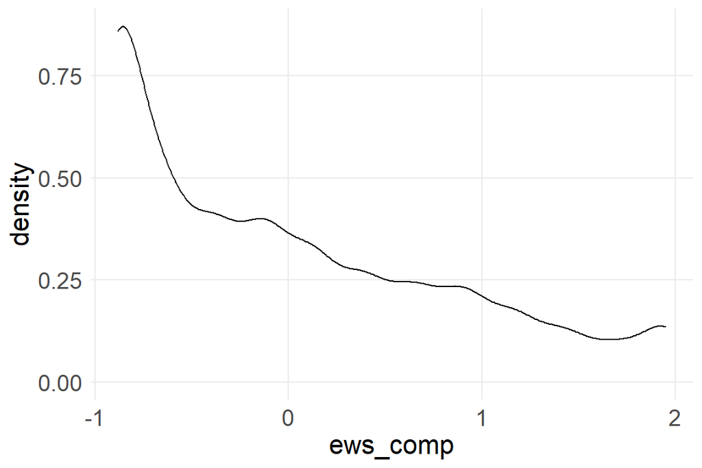

```r
ggplot(dat, aes(ews_comp)) +
  geom_density()
```

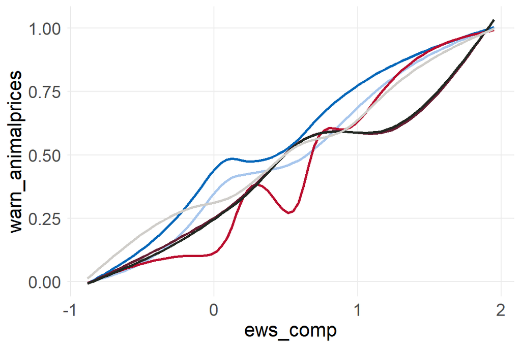

```r
ggplot(dat, aes(x=ews_comp)) +
  stat_smooth(aes(y=warn_animalprices), color=light_blue, se=F) +
  stat_smooth(aes(y=warn_prices), color=medium_blue, se=F) +
  stat_smooth(aes(y=warn_grazing), color=usaid_red, se=F) +
  stat_smooth(aes(y=warn_livestock), color=dark_red, se=F) +
  stat_smooth(aes(y=warn_crops), color=rich_black, se=F) +
  stat_smooth(aes(y=warn_hazards), color=light_grey, se=F)
```

```r
  #geom_point(aes(y=warn_animalprices), color=light_blue) +
  #geom_point(aes(y=warn_prices), color=medium_blue)
```

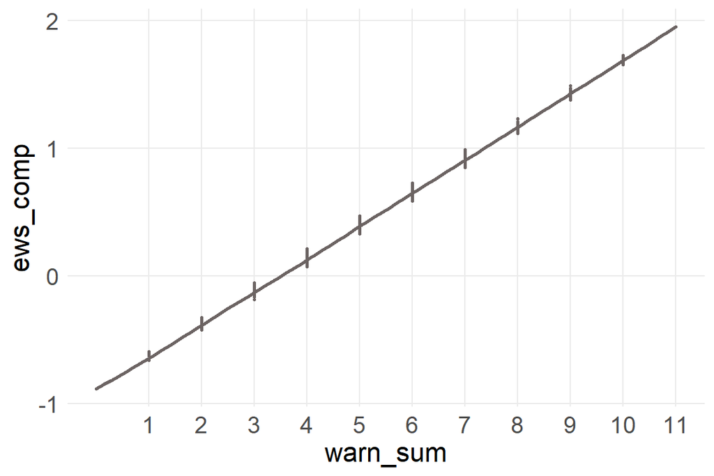

```r
ggplot(dat, aes(y=ews_comp)) +
  geom_point(aes(x=warn_sum), color=dark_grey, size=.6) +
  stat_smooth(aes(x=warn_sum), color=dark_grey, se=F) +
  scale_x_continuous(breaks=1:11)
```

#### 2.1.6.2 Emergency action plans

```r
frq(dat$q_612)
```

```
## Q 612: How effective was the plan in addressing the emergency? (x) <numeric>
## # total N=7872 valid N=1427 mean=2.50 sd=0.87
##
## Value |              Label |    N | Raw % | Valid % | Cum. %
## ------------------------------------------------------------
##     1 |      Not effective |  151 |  1.92 |   10.58 |  10.58
##     2 | A little effective |  630 |  8.00 |   44.15 |  54.73
##     3 |          Effective |  430 |  5.46 |   30.13 |  84.86
##     4 |     Very effective |  216 |  2.74 |   15.14 | 100.00
##  <NA> |               <NA> | 6445 | 81.87 |    <NA> |   <NA>
```

##### 2.1.6.2.1 frequencies

```r
names(grps)
```

```
##  [1] "grp_water"         "grp_land"          "grp_resource"
##  [4] "grp_credit"        "grp_savings"       "grp_help"
##  [7] "grp_relig"         "grp_mother"        "grp_women"
## [10] "grp_youth"         "grp_sports"        "grp_disaster"
## [13] "grp_raiding"       "grp_herding"       "grp_cattleprotect"
## [16] "grp_animalherding"
```

```r
emerg_temp <- svyrdat %>%
  summarize(q610 = survey_mean(emerg1, na.rm=T),
            q611 = survey_mean(emerg2, na.rm=T),
            q612 = survey_mean(emerg3, na.rm=T),
            q501l = survey_mean(emerg4, na.rm=T))

emerg_temp
```

Table 2.20:

| q610 | q610_se | q611 | q611_se | q612 | q612_se | q501l | q501l_se |
| --- | --- | --- | --- | --- | --- | --- | --- |
| 0.245 | 0.0141 | 0.193 | 0.0126 | 0.0737 | 0.00617 | 0.28 | 0.016 |

```r
emerg_mn <- emerg_temp %>%
  select(!contains("se")) %>%
  melt() %>%
  mutate(description=emerg_labs) %>%
  select(1,3,2)

emerg_mn
```

Table 2.21:

| variable | description | value |
| --- | --- | --- |
| q610 | Emergency action plan in place | 0.245 |
| q611 | Emergency plan addressed shock that household faced | 0.193 |
| q612 | Emergency plan successfully mitigated effect of shock | 0.0737 |
| q501l | Disaster planning group in community | 0.28 |

```r
emerg_se <- emerg_temp %>%
  select(contains("se")) %>%
  melt() %>%
  rename(se=value)

emerg_se
```

Table 2.21:

| variable | se |
| --- | --- |
| q610_se | 0.0141 |
| q611_se | 0.0126 |
| q612_se | 0.00617 |
| q501l_se | 0.016 |

```r
emerg_sum <- emerg_mn %>%
  cbind(emerg_se[,2]) %>%
  rename(percent=value,
         se = 4) %>%
  mutate(lower=percent-1.96*se,
         upper=percent+1.96*se) %>%
  arrange(desc(percent)) %>%
  relocate(description, .after=variable)

emerg_sum
```

Table 2.21:

| variable | description | percent | se | lower | upper |
| --- | --- | --- | --- | --- | --- |
| q501l | Disaster planning group in community | 0.28 | 0.016 | 0.248 | 0.311 |
| q610 | Emergency action plan in place | 0.245 | 0.0141 | 0.217 | 0.272 |
| q611 | Emergency plan addressed shock that household faced | 0.193 | 0.0126 | 0.169 | 0.218 |
| q612 | Emergency plan successfully mitigated effect of shock | 0.0737 | 0.00617 | 0.0616 | 0.0858 |

```r
write_csv(emerg_sum, here("output/tables/resilience/emergency weighted.csv"))

emerg_sum_gt <- emerg_sum %>%
  gt() %>%
  fmt_percent(3:6, decimals=1)

emerg_sum_gt
```

| variable | description | percent | se | lower | upper |
| --- | --- | --- | --- | --- | --- |
| q501l | Disaster planning group in community | 28.0% | 1.6% | 24.8% | 31.1% |
| q610 | Emergency action plan in place | 24.5% | 1.4% | 21.7% | 27.2% |
| q611 | Emergency plan addressed shock that household faced | 19.3% | 1.3% | 16.9% | 21.8% |
| q612 | Emergency plan successfully mitigated effect of shock | 7.4% | 0.6% | 6.2% | 8.6% |

```r
gtsave(emerg_sum_gt, here("output/tables/resilience/emergency weighted.rtf"))
```

```r
emerg <- dat %>%
  select(emerg1:emerg4)
head(emerg)
```

Table 2.22:

| emerg1 | emerg2 | emerg3 | emerg4 |
| --- | --- | --- | --- |
| 0 | 0 | 0 | 0 |
| 0 | 0 | 0 | 1 |
| 0 | 0 | 0 | 1 |
| 0 | 0 | 0 | 1 |
| 0 | 0 | 0 | 1 |
| 0 | 0 | 0 | 0 |

```r
map(emerg, frq)
```

```
## $emerg1
## x <numeric>
## # total N=7872 valid N=7872 mean=0.25 sd=0.43
##
## Value |    N | Raw % | Valid % | Cum. %
## ---------------------------------------
##     0 | 5921 | 75.22 |   75.22 |  75.22
##     1 | 1951 | 24.78 |   24.78 | 100.00
##  <NA> |    0 |  0.00 |    <NA> |   <NA>
##
## $emerg2
## x <numeric>
## # total N=7872 valid N=7872 mean=0.18 sd=0.39
##
## Value |    N | Raw % | Valid % | Cum. %
## ---------------------------------------
##     0 | 6436 | 81.76 |   81.76 |  81.76
##     1 | 1436 | 18.24 |   18.24 | 100.00
##  <NA> |    0 |  0.00 |    <NA> |   <NA>
##
## $emerg3
## x <numeric>
## # total N=7872 valid N=7872 mean=0.08 sd=0.27
##
## Value |    N | Raw % | Valid % | Cum. %
## ---------------------------------------
##     0 | 7226 | 91.79 |   91.79 |  91.79
##     1 |  646 |  8.21 |    8.21 | 100.00
##  <NA> |    0 |  0.00 |    <NA> |   <NA>
##
## $emerg4
## x <numeric>
## # total N=7872 valid N=7872 mean=0.26 sd=0.44
##
## Value |    N | Raw % | Valid % | Cum. %
## ---------------------------------------
##     0 | 5799 | 73.67 |   73.67 |  73.67
##     1 | 2073 | 26.33 |   26.33 | 100.00
##  <NA> |    0 |  0.00 |    <NA> |   <NA>
```

##### 2.1.6.2.2 IRT

```r
ltm_emerg <- ltm(emerg ~ z1)
ltm_emerg
```

```
##
## Call:
## ltm(formula = emerg ~ z1)
##
## Coefficients:
##         Dffclt  Dscrmn
## emerg1    0.70  34.207
## emerg2    1.03  51.983
## emerg3    1.41  22.979
## emerg4    2.15   0.523
##
## Log.Lik: -10963
```

```r
ltm_emerg_out <- coef(ltm_emerg) %>%
  as.data.frame() %>%
  rownames_to_column("variable") %>%
  mutate(description=emerg_labs) %>%
  select(1,4, difficulty=2,discrimination=3)

ltm_emerg_out
```

Table 2.23:

| variable | description | difficulty | discrimination |
| --- | --- | --- | --- |
| emerg1 | Emergency action plan in place | 0.7 | 34.2 |
| emerg2 | Emergency plan addressed shock that household faced | 1.03 | 52 |
| emerg3 | Emergency plan successfully mitigated effect of shock | 1.41 | 23 |
| emerg4 | Disaster planning group in community | 2.15 | 0.523 |

```r
write_csv(ltm_emerg_out, here("output/tables/resilience/emerg irt.csv"))

ltm_emerg_gt <- ltm_emerg_out %>%
  gt() %>%
  fmt_number(3:4,
             decimals=2)

ltm_emerg_gt
```

| variable | description | difficulty | discrimination |
| --- | --- | --- | --- |
| emerg1 | Emergency action plan in place | 0.70 | 34.21 |
| emerg2 | Emergency plan addressed shock that household faced | 1.03 | 51.98 |
| emerg3 | Emergency plan successfully mitigated effect of shock | 1.41 | 22.98 |
| emerg4 | Disaster planning group in community | 2.15 | 0.52 |

```r
gtsave(ltm_emerg_gt, here("output/tables/resilience/emerg irt.rtf"))
```

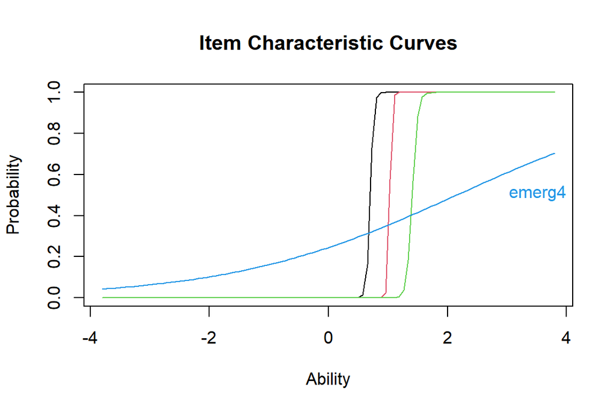

```r
plot(ltm_emerg, type="ICC")
```

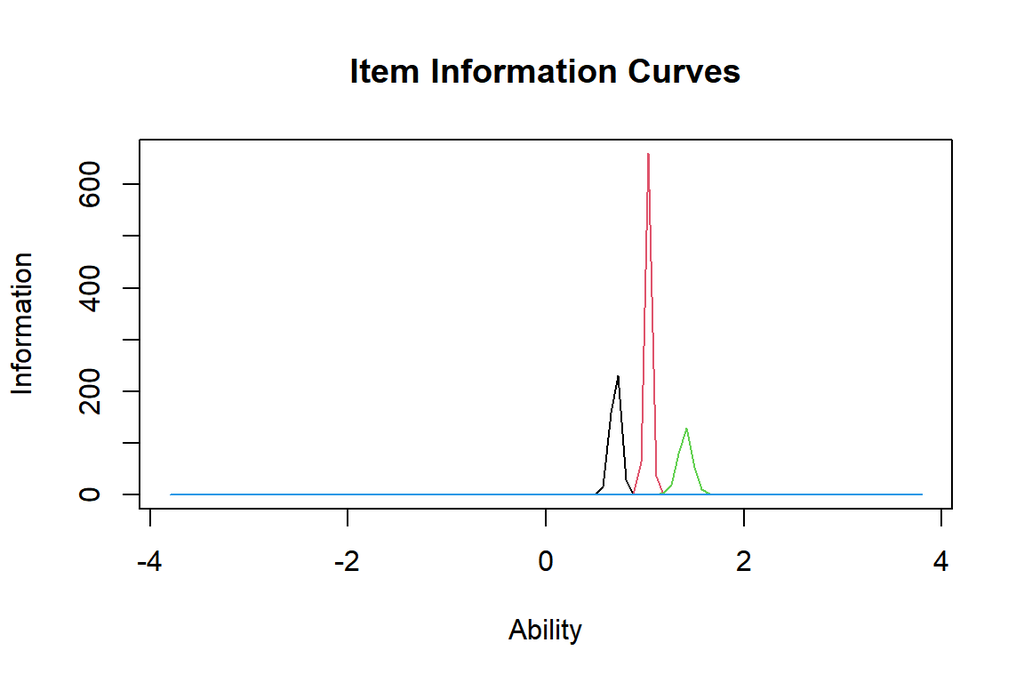

```r
plot(ltm_emerg, type="IIC")
```

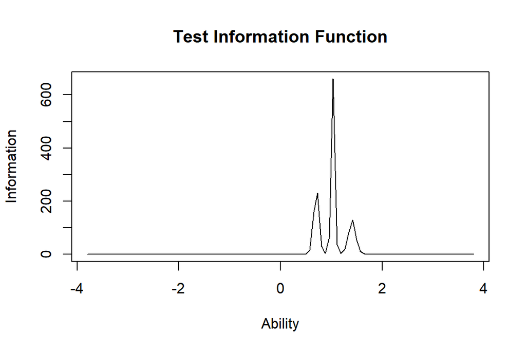

```r
plot(ltm_emerg,
     type="IIC",
     items=0)
```

```r
ltm_emerg2 <- ltm(emerg[,1:3] ~ z1)
ltm_emerg2
```

```
##
## Call:
## ltm(formula = emerg[, 1:3] ~ z1)
##
## Coefficients:
##         Dffclt  Dscrmn
## emerg1   0.701    33.9
## emerg2   1.033    53.3
## emerg3   1.410    22.8
##
## Log.Lik: -6554
```

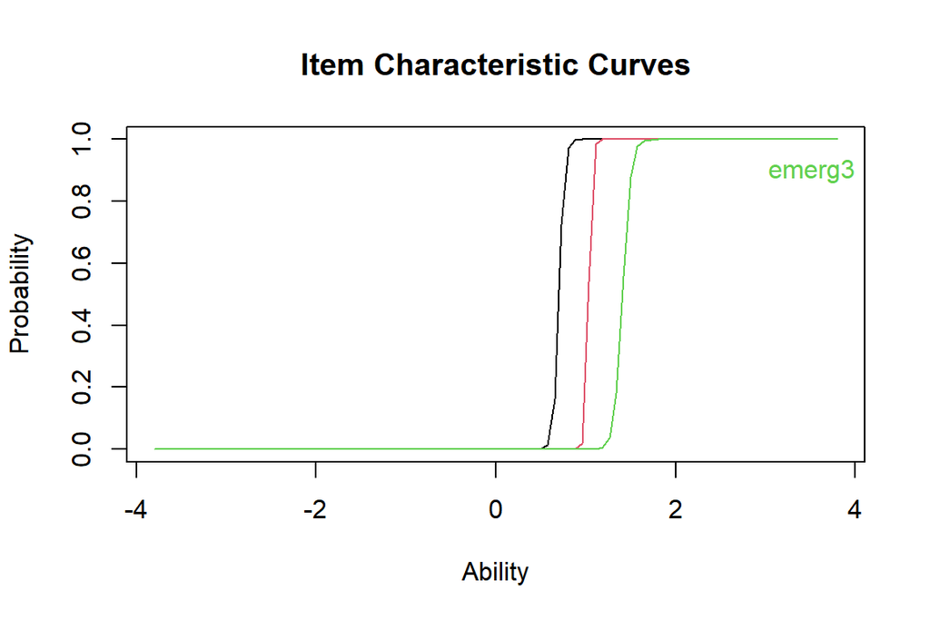

```r
plot(ltm_emerg2, type="ICC")
```

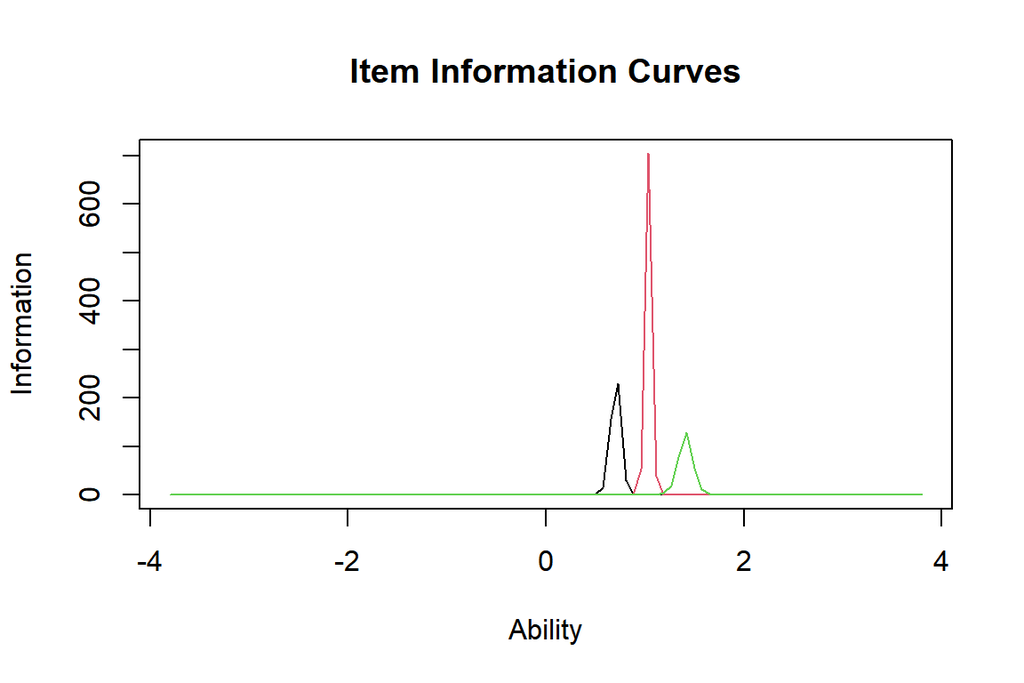

```r
plot(ltm_emerg2, type="IIC")
```

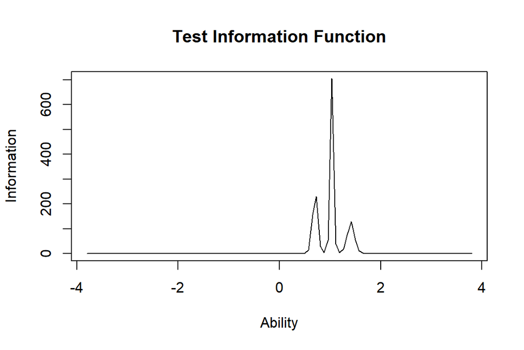

```r
plot(ltm_emerg2,
     type="IIC",
     items=0)
```